Ir al contenido

Ficha actualizada el 12 nov 2026

Ficha del establecimiento · RBD 9727

# Escuela Ciudad De Barcelona

Pedro Aguirre CerdaEscuela BásicaCon Programa de Integración EscolarJornada escolar completa

Felipe Sebastian Rodriguez Rojas

Dirección del establecimiento

🎒Matrícula

217

0 respecto de 2025

📅Asistencia promedio

88,0 %

5,3 puntos sobre el promedio del SLEP

📇Estudiantes prioritarios

73,2 %

Concentración declarada (marzo)

📊SIMCE Lectura 4° básico

262 pts

+4 pts respecto del SLEP

¿Primera vez leyendo una ficha?Empieza por la ficha en cifras[Guía para leer los datos (se abre en otra pestaña)](https://datos.slepsantarosa.workers.dev/guia.html)

## La ficha en cifras

Cada cifra enlaza a su sección, donde está explicada y comparada con el SLEP.

📇Estudiantes prioritarios73,2 %Concentración declarada (marzo)Ver sección: Estudiantes prioritarios →

🎒Matrícula2170 respecto de 2025Ver sección: Matrícula →

📅Asistencia promedio88,0 %5,3 puntos sobre el promedio del SLEPVer sección: Asistencia promedio →

🪑Ocupación de cursos63,8 %217 de 340 cupos declaradosVer sección: Ocupación de cursos →

🤝Estudiantes en el PIE5324,4 % de la matrículaVer sección: Estudiantes en el PIE →

🚶Retiros en 202673,2 % de la matrículaVer sección: Retiros en 2026 →

📗Aprobación97,8 %Año escolar 2025Ver sección: Aprobación →

📊SIMCE Lectura 4° básico262 pts+4 pts respecto del SLEPVer sección: SIMCE Lectura 4° básico →

🏷️Categoría de desempeñoMedio-bajoEducación básica · 2019Ver sección: Categoría de desempeño →

💛Clima de convivencia escolar81,0De 0 a 100 · 2025Ver sección: Clima de convivencia escolar →

🧭Lectura en Nivel III del DIA11,7 %El nivel más alto · monitoreo intermedio 2026 · 163 evaluadosVer sección: Lectura en Nivel III del DIA →

👥Funcionarios4425 docentes y 19 asistentes de la educaciónVer sección: Funcionarios →

📈Docentes en tramo avanzado o superior56 %14 de 25 docentesVer sección: Docentes en tramo avanzado o superior →

📜Acciones del plan de mejoramiento23Plan 2025, en 4 dimensionesVer sección: Acciones del plan de mejoramiento →

⭐SNED 2026-2027SeleccionadoÍndice de 69,6 sobre 100Ver sección: SNED 2026-2027 →

🔗Convenios de uso de espacios1Organizaciones que usan sus espaciosVer sección: Convenios de uso de espacios →

🛡️Denuncias registradas2Última en 2025Ver sección: Denuncias registradas →

🚨Hechos delictuales registrados1Último en 28 abr 2025Ver sección: Hechos delictuales registrados →

🗺️Niños y jóvenes en el barrio3.548De 0 a 17 años, a 800 m a la redondaVer sección: Niños y jóvenes en el barrio →

📍Estudiantes de la misma comuna68 %Viven en Pedro Aguirre Cerda, la comuna del establecimientoVer sección: Estudiantes de la misma comuna →

Capítulo

¿Qué establecimiento es y qué ofrece?

## 🏫El establecimiento

- 📇Identificación y contacto
- 🎭Vida escolar y participación

El establecimiento · Identificación y contactoDatos al 16 oct 2026

### 📇Identificación y contacto

¿Qué establecimiento es y cómo contactarlo?

Escuela Básica en funcionamiento en Pedro Aguirre Cerda, imparte enseñanza básica, educación parvularia y atiende a 217 estudiantes.

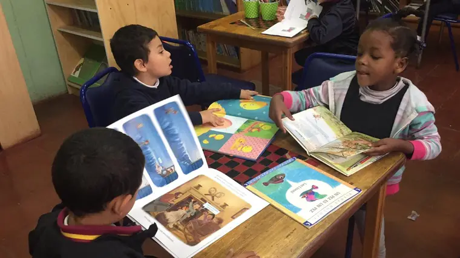

[figure not shown]

📷Fotografías del establecimiento

Concentración de estudiantes prioritarios

73,2 %

Estudiantes cuya situación socioeconómica puede afectar su rendimiento, según el Ministerio de Educación.

Índice de vulnerabilidad (IVE)

92,0 %

Su comuna: 85,5 %. Lo calcula la JUNAEB y decide a qué establecimientos llegan primero los programas de apoyo.

Cursos en funcionamiento

En enseñanza básica y educación parvularia

Programas y convenios

2

Programa de Integración Escolar · Jornada Escolar Completa

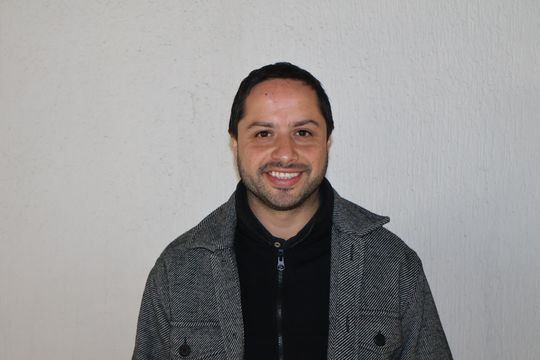

👤Dirección del establecimiento

Felipe Sebastian Rodriguez Rojas

✉️escuelaciudaddebarcelona@slepsantarosa.cl

📱Celular: +56 9 7776 3183

☎️Teléfono del establecimiento: 43144766

🤝Asesoría técnica del SLEP: Diego Jara Asquet · diego.jara@slepsantarosa.gob.cl

📍Dónde queda

Maya 5961, Pedro Aguirre Cerda.

[interactive chart not shown]

Fuente: Coordenadas del directorio consolidado · [Abrir en Google Maps](https://www.google.com/maps/search/?api=1&query=-33.497472,-70.690213)

#### Identificación

**RBD**

9727-6

**Tipo de establecimiento**

Escuela Básica

**Dependencia**

Servicio Local de Educación Pública Santa Rosa

**Estado**

Funcionando

**Comuna**

Pedro Aguirre Cerda

#### Cómo contactarlo

**Dirección**

Maya 5961

**Teléfono**

43144766

**Correo**

escuelaciudaddebarcelona@slepsantarosa.cl

#### Equipo y apoyo técnico

**Dirección**

Felipe Sebastian Rodriguez Rojas

**Unidad Técnico Pedagógica**

utp.escuelaciudaddebarcelona@slepsantarosa.cl

**Inspectoría**

inspectoria.escuelaciudaddebarcelona@slepsantarosa.cl

**Asesoría técnica del SLEP**

Diego Jara Asquet

**Correo de la asesoría**

diego.jara@slepsantarosa.gob.cl

#### Programas y convenios vigentes

Programa de Integración Escolar (PIE)Jornada Escolar CompletaSin PACE

#### Apoyos profesionales al aprendizaje

ReforzamientoPsicopedagogíaPsicologíaProfesor o profesora de educación especialTrabajo socialFonoaudiologíaOtro: Terapeuta ocupacionalOrientaciónOrientación vocacional

#### Necesidades educativas que atiende

Tipos de necesidades educativas especiales que el establecimiento declara atender.

Discapacidad intelectualDiscapacidad motoraTrastorno del espectro autistaDificultades de aprendizajeTrastorno específico del lenguajeDéficit atencionalFuncionamiento intelectual limítrofe

#### Infraestructura declarada

Biblioteca (CRA)Computación con internetSala audiovisualCancha deportivaAccesibilidad para NEEOtro: CasinoLaboratorio de cienciasSala de usos múltiplesGimnasio techado

#### Documentos públicos

[Proyecto Educativo Institucional (PEI)](https://wwwfs.mineduc.cl/Archivos/infoescuelas/documentos/9727/ProyectoEducativo9727.pdf)[Reglamento de convivencia](https://wwwfs.mineduc.cl/Archivos/infoescuelas/documentos/9727/ReglamentodeConvivencia9727.pdf)[Reglamento de evaluación](https://wwwfs.mineduc.cl/Archivos/infoescuelas/documentos/9727/ReglamentoDeEvaluacion9727.pdf)

**¿Cómo se lee este dato?**

**Qué es**

La identificación oficial del establecimiento y las vías para comunicarse con él.

**De dónde sale**

Del directorio consolidado que el equipo actualiza cada mes con el registro oficial del Ministerio de Educación y los datos del propio Servicio Local.

**Cómo leerlo**

El **RBD** es el número con que el Ministerio identifica a cada establecimiento: sirve para buscarlo en cualquier sistema público. **Dependencia** indica quién lo administra; desde el traspaso, es el Servicio Local de Educación Pública.

**Referencia**

La **concentración de estudiantes prioritarios** es el porcentaje de estudiantes cuya situación socioeconómica puede dificultar su trayectoria escolar; el Ministerio la usa para asignar la subvención escolar preferencial.

**Lo que no dice**

Que un establecimiento tenga más programas no significa mejores resultados: son convenios a los que se postula según su proyecto y su matrícula.

**Para saber más**

[Guía para leer los datos: Cómo leer una ficha (se abre en otra pestaña)](https://datos.slepsantarosa.workers.dev/guia.html#empezar)

El establecimiento · Vida escolar y participación

### 🎭Vida escolar y participación

¿Quiénes participan en la comunidad educativa?

El establecimiento tiene centro de padres y apoderados, con personalidad jurídica vigente y cuenta con centro de estudiantes.

Centro de padres

Constituido

Personalidad jurídica: vigente

Centro de estudiantes

Constituido

Lo integran estudiantes del establecimiento

Consejo escolar

Con representante del sostenedor

Bruno Cortés González

#### Centro de padres y apoderados

**Personalidad jurídica**

Vigente

**Certificado de directorio vigente**

DPJ_ESCUELA CIUDAD DE BARCELONA.pdf

**Última elección del directorio**

**Próxima elección**

Para contactarlo, escribe al establecimiento: sus datos están en «Identificación y contacto».

#### Centro de estudiantes

El establecimiento tiene centro de estudiantes constituido. Lo integran estudiantes del propio establecimiento.

#### Consejo escolar

**Representante del sostenedor**

Bruno Cortés González

**Acompañamiento del SLEP**

Bruno Cortés González

**¿Cómo se lee este dato?**

**Qué es**

Las tres instancias de participación que la ley exige a cada establecimiento: el **consejo escolar** (donde se encuentran dirección, docentes, asistentes, apoderados y estudiantes), el **centro de padres** y el **centro de estudiantes**.

**De dónde sale**

Del registro que mantiene el Servicio Local con los establecimientos, actualizado cuando hay elecciones o cambios de directiva.

**Cómo leerlo**

La **personalidad jurídica** permite al centro de padres administrar recursos propios. Un centro sin directorio vigente no puede firmar convenios ni recibir aportes.

**Lo que no dice**

Que una instancia figure constituida no dice cuán activa es: el registro solo guarda su estado formal.

Capítulo

¿A quiénes educa y cómo avanzan durante el año?

## 🧒Estudiantes

- 🎒Matrícula
- 📅Asistencia
- 🪑Ocupación de cursos
- 🤝Programa de Integración Escolar (PIE)
- 🚶Retiros y traslados

Estudiantes · MatrículaDatos de septiembre de 2026

### 🎒Matrícula

¿Cuántos estudiantes tiene y cómo ha cambiado?

En septiembre de 2026 estudian 217 estudiantes en el establecimiento, la misma cantidad que en 2025. El 44,7 % son mujeres y el 16,6 % tiene nacionalidad extranjera.

Estudiantes matriculados

217

0 estudiantes respecto de 2025 (0,0 %)

82

SLEP 300217

915Rango de los establecimientos del SLEP

Estudiantes por curso

21,7

10 cursos en funcionamiento

10,5

SLEP 23,821,7

39,5Rango de los establecimientos del SLEP

Estudiantes mujeres

44,7 %

97 de 217 estudiantes

0,0 %

SLEP 46,5 %44,7 %

100,0 %Rango de los establecimientos del SLEP

Estudiantes extranjeros

16,6 %

36 de 217 estudiantes

6,5 %

SLEP 29,8 %16,6 %

77,6 %Rango de los establecimientos del SLEP

La matrícula se ha mantenido estable

Estudiantes matriculados en septiembre de cada año, según el registro mensual del SIGE.

[interactive chart not shown]

Fuente: SIGE, MINEDUC.

#### Género, nacionalidad y origen

Cómo se reparten los 217 estudiantes de septiembre de 2026, según lo que el establecimiento registra de cada uno en el SIGE. Los porcentajes son sobre el total de estudiantes.

#### Por género

- **Mujeres**44,7 % · 97 estudiantes
- **Hombres**55,3 % · 120 estudiantes

#### Por nacionalidad

- **Chilena**83,4 % · 181 estudiantes
- **Extranjera**16,6 % · 36 estudiantes

#### País de origen distinto de Chile

- Venezuela7,8 %17
- Otros10,6 %23

#### Pueblo originario

- **Pertenece a un pueblo originario**7,4 % · 16 estudiantes
- **No pertenece**86,2 % · 187 estudiantes
- **Sin registro**6,5 % · 14 estudiantes

Los grupos de menos de 5 estudiantes se suman en «Otros» para no identificar a nadie. País de origen: la tarjeta muestra los países declarados en el registro, sin contar Chile (40 estudiantes). Es un dato distinto de la nacionalidad (36 estudiantes de nacionalidad extranjera) y no siempre coincide con ella: muestra lo que el establecimiento registró, no el total de estudiantes de cada país.

**¿Cómo se lee este dato?**

**Qué es**

La cantidad de estudiantes inscritos en el establecimiento en el mes de corte, y cómo se reparte ese total por género, nacionalidad, país de origen y pueblo originario.

**De dónde sale**

Del Sistema de Información General de Estudiantes (SIGE), que cada establecimiento actualiza mes a mes. El género, la nacionalidad, el país de origen y el pueblo originario son los que el establecimiento registra al matricular a cada estudiante.

**Cómo leerlo**

Mira la tendencia de varios años antes que un mes aislado: la matrícula se mueve todo el año por traslados, retiros y nuevas incorporaciones. En el desglose, los grupos de menos de 5 estudiantes se suman en «Otros» para no identificar a nadie; si aun así no quedan al menos dos grupos, ese desglose no se muestra.

**Lo que no dice**

Que un establecimiento tenga más estudiantes no significa que enseñe mejor: el tamaño depende de la infraestructura, de los cupos declarados y del barrio. En el desglose, una diferencia chica entre dos grupos puede ser un solo estudiante: mira también el número, no solo el porcentaje. La nacionalidad y el país de origen son dos datos distintos del registro y no siempre calzan: un estudiante de nacionalidad extranjera puede figurar con Chile como país de origen. Por eso sus cifras no tienen por qué coincidir.

**Para saber más**

[Guía para leer los datos: Matrícula (se abre en otra pestaña)](https://datos.slepsantarosa.workers.dev/guia.html#matricula)

**Ver la matrícula curso por curso (10 cursos)**

Matrícula por curso

| Curso | Estudiantes | % del total |
| --- | --- | --- |
| Pre-kínder A | 13 | 6,0 % |
| Kínder A | 16 | 7,4 % |
| 1° Básico A | 21 | 9,7 % |
| 2° Básico A | 21 | 9,7 % |
| 3° Básico A | 19 | 8,8 % |
| 4° Básico A | 22 | 10,1 % |
| 5° Básico A | 27 | 12,4 % |
| 6° Básico A | 24 | 11,1 % |
| 7° Básico A | 31 | 14,3 % |
| 8° Básico A | 23 | 10,6 % |

Estudiantes · AsistenciaDatos de septiembre de 2026

### 📅Asistencia

¿Cuántos estudiantes van a clases todos los días?

De marzo a septiembre de 2026, los estudiantes asistieron en promedio 88,0 % de los días con clases: 5,3 puntos sobre el promedio del SLEP (82,8 %). Entre las mujeres la asistencia fue de 87,6 % y entre los hombres, de 88,4 %.

Asistencia promedio del año

88,0 %

−3,9 puntos respecto de 2025

49,4 %

SLEP 82,8 %88,0 %

90,4 %Rango de los establecimientos del SLEP

Asistencia de septiembre

91,3 %

217 estudiantes en 10 cursos

Curso con menor asistencia

81,6 %

1° Básico A · 6,4 puntos bajo el promedio del establecimiento

1 de 7 meses quedan bajo el 85 %, el más bajo en julio

Asistencia promedio del establecimiento en cada mes de 2026, ponderada por la matrícula de cada curso.

[interactive chart not shown]

Fuente: SIGE, MINEDUC.

#### Asistencia por género, nacionalidad y origen

Asistencia promedio de marzo a septiembre de 2026 de cada grupo, calculada igual que la del establecimiento: ponderada por la cantidad de estudiantes del grupo en cada curso. La raya marca el promedio del establecimiento (88,0 %). Bajo el nombre de cada grupo va su cantidad de estudiantes en septiembre.

#### Por género

- Mujeres97 estudiantes87,6 %
- Hombres120 estudiantes88,4 %

Promedio del establecimiento: **88,0 %**

#### Por nacionalidad

- Chilena181 estudiantes88,0 %
- Extranjera36 estudiantes88,5 %

Promedio del establecimiento: **88,0 %**

#### Por país de origen distinto de Chile

- Venezuela17 estudiantes85,5 %
- Otros23 estudiantes89,7 %

Promedio del establecimiento: **88,0 %**

La asistencia de un grupo se publica solo si tuvo 10 o más estudiantes en todos los meses del período, para no identificar a nadie; los grupos más chicos se suman en «Otros». Por esa regla no se muestra la asistencia por pueblo originario. Por país de origen se muestran los países declarados en el registro, sin contar Chile. Es un dato distinto de la nacionalidad y no siempre coincide con ella: las cifras describen solo a quienes tienen ese país registrado, no a todos los estudiantes de cada país.

**¿Cómo se lee este dato?**

**Qué es**

La proporción entre los días que un estudiante va a clases y los días que hubo clases. La asistencia de un curso, de un grupo de estudiantes o de un establecimiento es el promedio de esos porcentajes.

**De dónde sale**

El establecimiento registra la asistencia todos los días y la declara cada mes en el Sistema de Información General de Estudiantes (SIGE). Esa misma asistencia es la base de la subvención.

**Cómo leerlo**

Compara cada mes con el mismo mes del año anterior: marzo y diciembre se leen distinto por el ingreso escalonado y el cierre del año. En el desglose por género, nacionalidad y origen, la asistencia de un grupo se publica solo si tuvo 10 o más estudiantes durante todo el período, para no identificar a nadie.

**Referencia**

El Decreto 67 de 2018 exige al menos 85 % de asistencia en el año para ser promovido, con excepciones que autoriza la dirección. El Centro de Estudios del Ministerio usa cuatro categorías: destacada (97 % o más), normal (90 a 97 %), inasistencia reiterada (85 a 90 %) e inasistencia grave (85 % o menos).

**Lo que no dice**

Cuántos estudiantes faltan mucho. Un promedio alto puede esconder a varios estudiantes bajo el 85 %: para saberlo hay que mirar caso a caso, no el promedio. Tampoco que un grupo falte más que otro por una diferencia de uno o dos puntos: en grupos de menos de 20 estudiantes el promedio cambia mucho con un solo caso, y el dato no dice por qué falta cada estudiante.

**Para saber más**

[Guía para leer los datos: Asistencia (se abre en otra pestaña)](https://datos.slepsantarosa.workers.dev/guia.html#asistencia)

**Ver la asistencia curso por curso (10 cursos)**

Asistencia por curso, marzo a septiembre de 2026

| Curso | Estudiantes | Asistencia del año | Situación |
| --- | --- | --- | --- |
| Pre-kínder A | 12 | 90,4 % | Sobre el umbral |
| Kínder A | 15 | 84,7 % | Bajo el umbral |
| 1° Básico A | 19 | 81,6 % | Bajo el umbral |
| 2° Básico A | 21 | 89,4 % | Sobre el umbral |
| 3° Básico A | 18 | 88,1 % | Sobre el umbral |
| 4° Básico A | 21 | 88,6 % | Sobre el umbral |
| 5° Básico A | 26 | 88,4 % | Sobre el umbral |
| 6° Básico A | 23 | 90,5 % | Sobre el umbral |
| 7° Básico A | 30 | 87,2 % | Sobre el umbral |
| 8° Básico A | 22 | 90,8 % | Sobre el umbral |

Estudiantes · Ocupación de cursosDatos de septiembre de 2026

### 🪑Ocupación de cursos

¿Cuántos cupos están ocupados en cada curso?

En septiembre de 2026, 217 estudiantes ocupan los 340 cupos que el establecimiento declaró al Sistema de Admisión Escolar (SAE): 63,8 % de ocupación, con 123 cupos disponibles.

Ocupación de los cupos declarados

63,8 %

217 estudiantes en 340 cupos

33,3 %

SLEP 68,3 %63,8 %

111,2 %Rango de los establecimientos del SLEP

Cursos sobre su capacidad declarada

0

de 10 cursos con cupos declarados

Cupos disponibles

123

repartidos en 10 cursos

Quedan 123 cupos disponibles, repartidos en 10 cursos

Estudiantes matriculados en septiembre de 2026 (barra azul) sobre los cupos que el establecimiento declaró al SAE (barra gris).

[interactive chart not shown]

Fuente: SIGE y Sistema de Admisión Escolar, MINEDUC.

**¿Cómo se lee este dato?**

**Qué es**

La ocupación compara los estudiantes efectivamente matriculados en cada curso con los cupos que el establecimiento declaró al Sistema de Admisión Escolar (SAE).

**De dónde sale**

Los cupos los declara el propio establecimiento en el proceso del SAE; la matrícula sale del registro mensual del SIGE. Las dos cifras viajan en la misma tabla, curso por curso.

**Cómo leerlo**

El 100 % significa que todos los cupos declarados están tomados. Pasar del 100 % quiere decir que hay más estudiantes que cupos: casi siempre es señal de que la capacidad declarada al SAE quedó desactualizada, no de que sobren estudiantes en la sala.

**Referencia**

No hay un umbral oficial: la referencia es la capacidad declarada (100 %). Entre los 53 establecimientos del SLEP que declaran cupos, la ocupación va de 33,3 % a 111,2 %, con un promedio de 68,3 %.

**Lo que no dice**

Cuánto espacio físico real tiene el establecimiento. Un curso puede aparecer con cupos libres porque se reservaron vacantes para el SAE o porque la capacidad declarada es mayor que la que se usa.

**Para saber más**

[Guía para leer los datos: Matrícula (se abre en otra pestaña)](https://datos.slepsantarosa.workers.dev/guia.html#matricula)

**Ver los cupos curso por curso (10 cursos)**

Cupos declarados y matrícula por curso, septiembre de 2026

| Curso | Estudiantes | Cupos declarados | Ocupación | Cupos disponibles |
| --- | --- | --- | --- | --- |
| Pre-kínder A | 13 | 30 | 43,3 % | 17 |
| Kínder A | 16 | 30 | 53,3 % | 14 |
| 1° Básico A | 21 | 35 | 60,0 % | 14 |
| 2° Básico A | 21 | 35 | 60,0 % | 14 |
| 3° Básico A | 19 | 35 | 54,3 % | 16 |
| 4° Básico A | 22 | 35 | 62,9 % | 13 |
| 5° Básico A | 27 | 35 | 77,1 % | 8 |
| 6° Básico A | 24 | 35 | 68,6 % | 11 |
| 7° Básico A | 31 | 35 | 88,6 % | 4 |
| 8° Básico A | 23 | 35 | 65,7 % | 12 |

Estudiantes · PIEDatos de abril de 2026

### 🤝Programa de Integración Escolar (PIE)

¿Cuántos estudiantes reciben apoyos del Programa de Integración Escolar?

53 estudiantes reciben apoyos del Programa de Integración Escolar: 24,4 % de la matrícula, 5,6 puntos sobre el promedio del SLEP (18,8 %).

Estudiantes en el PIE

53

de 217 estudiantes matriculados en septiembre de 2026

3

SLEP 5353

140Rango de los establecimientos del SLEP

Porcentaje de la matrícula

24,4 %

+5,6 puntos respecto del promedio del SLEP (18,8 %)

1,7 %

SLEP 18,8 %24,4 %

34,2 %Rango de los establecimientos del SLEP

Diagnóstico más frecuente

19estudiantes

Lenguaje (TEL) · 36 % de quienes están en el PIE

La cobertura del PIE se ha mantenido estable desde 2024

Estudiantes con necesidades educativas especiales registrados cada año por el Área de Inclusión Educativa del SLEP. Es un catastro distinto de la nómina del SIGE que alimenta las cifras clave, por eso los totales no coinciden exactamente.

[interactive chart not shown]

Fuente: PIE Territorial, Área de Inclusión Educativa del SLEP Santa Rosa.

#### Quiénes reciben los apoyos

Los 53 estudiantes del programa en abril de 2026, según la nómina del SIGE. Cada tarjeta mira una sola característica.

#### Por tipo de necesidad

- **Necesidad permanente**26,4 % · 14 estudiantes
- **Necesidad transitoria**73,6 % · 39 estudiantes

#### Por género

- **Mujeres**35,8 % · 19 estudiantes
- **Hombres**64,2 % · 34 estudiantes

#### Por nivel de enseñanza

- Educación parvularia9 %5
- Educación básica91 %48

No se muestra el desglose por nacionalidad: tiene grupos de menos de 5 estudiantes.

**¿Cómo se lee este dato?**

**Qué es**

El Programa de Integración Escolar (PIE) entrega apoyos adicionales —profesionales de apoyo, horas de trabajo conjunto con los docentes y materiales— a los estudiantes que tienen una necesidad educativa especial (NEE) diagnosticada, dentro de la misma sala de clases.

**De dónde sale**

El detalle por estudiante sale de la nómina PIE del SIGE (abril de 2026) y la serie por año, del catastro del Área de Inclusión Educativa del SLEP. Son dos registros distintos, con fechas distintas: sus totales no calzan exactamente.

**Cómo leerlo**

Una necesidad «permanente» acompaña a la persona durante toda su vida —por ejemplo una discapacidad intelectual, sensorial o motora— y da derecho a apoyos en toda la trayectoria escolar. Una necesidad «transitoria» se presenta en un período de la escolaridad y se espera que se supere con apoyo, como las dificultades del aprendizaje o del lenguaje. En la mayoría de los establecimientos las transitorias son las más numerosas.

**Referencia**

En el SLEP Santa Rosa el promedio es 18,8 % de la matrícula. El programa se rige por el Decreto 170 del Ministerio de Educación, que define qué diagnósticos puede atender y qué apoyos financia.

**Lo que no dice**

Un porcentaje alto de estudiantes en el PIE no es un mal resultado: habla de cuántos estudiantes tienen apoyos reconocidos y financiados, no de cómo enseña el establecimiento. Tampoco dice cuántos estudiantes necesitan apoyo, porque solo cuenta a quienes ya tienen un diagnóstico vigente y entraron al programa. Por lo mismo, las diferencias por género, nivel o nacionalidad muestran a quiénes se ha diagnosticado, no quiénes necesitan más apoyo. Los grupos de menos de 5 estudiantes se suman en «Otros» para no identificar a nadie, y con menos de 5 estudiantes en el programa no se muestra ningún desglose.

**Ver el detalle por diagnóstico**

Estudiantes del PIE por diagnóstico

| Diagnóstico | Tipo de necesidad | Estudiantes | % del PIE |
| --- | --- | --- | --- |
| Lenguaje (TEL) | Transitoria | 19 | 35,8 % |
| Dificultades del aprendizaje | Transitoria | 12 | 22,6 % |
| Espectro autista (TEA) | Permanente | 7 | 13,2 % |
| Otros diagnósticos transitorios | Transitoria | 8 | 15,1 % |
| Otros diagnósticos permanentes | Permanente | 7 | 13,2 % |

Estudiantes · Retiros y trasladosDatos de julio de 2026

### 🚶Retiros y traslados

¿Cuántos estudiantes se fueron durante el año y por qué?

En 2026 se registraron 7 retiros: 3,2 % de la matrícula, 10,5 puntos bajo el promedio del SLEP (13,7 %).

Retiros registrados en 2026

7

−10 respecto del mismo período de 2025 (17 retiros)

1

SLEP 397

155Rango de los establecimientos del SLEP

Porcentaje de la matrícula

3,2 %

−10,5 puntos respecto del promedio del SLEP (13,7 %)

0,6 %

SLEP 13,7 %3,2 %

103,3 %Rango de los establecimientos del SLEP

Dejaron el establecimiento

7estudiantes

con al menos un retiro registrado en el año

Abril y julio son los meses con más retiros: 2 retiros en cada uno

Retiros registrados cada mes de 2026, desde marzo hasta julio.

[interactive chart not shown]

Fuente: Registro de retiros y traslados del SIGE, MINEDUC.

No se muestra el desglose por género, nacionalidad, curso, comuna de destino y destino: tienen grupos de menos de 5 estudiantes.

**¿Cómo se lee este dato?**

**Qué es**

Un retiro es el registro que hace el establecimiento en el SIGE cuando un estudiante deja su curso durante el año escolar. No todos los retiros son iguales: la mayoría son traslados, es decir, el estudiante se matricula en otro establecimiento y sigue estudiando.

**De dónde sale**

Del registro de retiros y traslados del SIGE, cruzado con la matrícula vigente para saber dónde quedó cada estudiante. El corte de estos datos es julio de 2026.

**Cómo leerlo**

Distingue el «traslado a otro establecimiento» —el estudiante sigue en el sistema escolar, dentro o fuera del SLEP— del «retiro sin matrícula posterior», que es el que conviene mirar de cerca, porque puede anticipar una desvinculación del sistema. Los meses de marzo y diciembre concentran movimientos administrativos —regularizaciones de inicio de año y cierres de curso—, así que un alza en esos meses no significa lo mismo que un alza en mitad del año. Los desgloses por género, nacionalidad, nivel y destino cuentan estudiantes, no movimientos, y dejan fuera los cambios de curso internos.

**Referencia**

En el SLEP Santa Rosa los retiros equivalen en promedio a 13,7 % de la matrícula en lo que va de 2026. La comparación se hace con el mismo corte para todos los establecimientos.

**Lo que no dice**

El retiro no es lo mismo que la deserción: solo la matrícula del año siguiente confirma si un estudiante dejó de estudiar. Y como el año todavía no termina, la cifra seguirá subiendo hasta diciembre: no se puede comparar con el total de un año cerrado. Los desgloses tampoco dicen por qué se fue cada estudiante, y con tan pocos casos una diferencia entre grupos puede ser casualidad. Los grupos de menos de 5 estudiantes se suman en «Otros» para no identificar a nadie.

**Para saber más**

[Guía para leer los datos: Matrícula (se abre en otra pestaña)](https://datos.slepsantarosa.workers.dev/guia.html#matricula)

**Ver el detalle mes a mes**

Retiros de 2026 por mes

| Mes del retiro | Retiros |
| --- | --- |
| Marzo | 1 |
| Abril | 2 |
| Mayo | 1 |
| Junio | 1 |
| Julio | 2 |
| Total | 7 |

Capítulo

¿Qué están aprendiendo sus estudiantes?

## 📚Aprendizajes

- 📗Rendimiento
- 📊SIMCE
- 🏷️Categoría de desempeño
- 💛Desarrollo personal y social
- 🧭Diagnóstico Integral de Aprendizajes (DIA)

Aprendizajes · RendimientoDatos de año escolar 2025

### 📗Rendimiento

¿Cuántos estudiantes aprobaron el año?

En 2025, 97,8 % de los estudiantes que terminaron el año fue promovido de curso, 1,3 puntos sobre el promedio del SLEP.

Estudiantes promovidos

97,8 %

+0,0 puntos respecto de 2024

49,7 %

SLEP 96,5 %97,8 %

100,0 %Rango de los establecimientos del SLEP

Nota promedio del establecimiento

6,0

Promedio general de 186 estudiantes con nota final

5,4

SLEP 5,96,0

6,3Rango de los establecimientos del SLEP

Reprobados por inasistencia

0

De 4 estudiantes reprobados en 2025

La aprobación se mantiene estable

Porcentaje de estudiantes promovidos sobre los que terminaron el año en el establecimiento (no incluye retirados ni trasladados).

Promedio del SLEP en 2025: 96,5 %

[interactive chart not shown]

Fuente: Actas de rendimiento, SIGE.

#### Aprobación y notas por género y nacionalidad

Resultados de 2025 de quienes terminaron el año, mirando una característica a la vez. La raya marca el valor de todo el establecimiento.

#### Aprobación por género

- Mujeres85 estudiantes97,6 %
- Hombres101 estudiantes98,0 %

Aprobación del establecimiento: **97,8 %**

#### Nota promedio por género

- Mujeres85 con nota final6,1
- Hombres101 con nota final5,9

Nota del establecimiento: **6,0**

#### Aprobación por nacionalidad

- Chilena157 estudiantes97,5 %
- Extranjera29 estudiantes100,0 %

Aprobación del establecimiento: **97,8 %**

#### Nota promedio por nacionalidad

- Chilena157 con nota final6,0
- Extranjera29 con nota final6,0

Nota del establecimiento: **6,0**

**¿Cómo se lee este dato?**

**Qué es**

El resultado del año escolar de cada estudiante: promovido al curso siguiente o reprobado.

**De dónde sale**

De las actas de rendimiento que el establecimiento entrega al Ministerio al cerrar el año, a través del SIGE.

**Cómo leerlo**

La aprobación se calcula sobre quienes **terminaron el año** en el establecimiento. Los estudiantes **retirados** o **trasladados** se cuentan aparte (sección Retiros y traslados), porque su resultado final lo registra otro establecimiento. La nota promedio es el promedio general de cada estudiante con nota final, no un promedio de cursos.

**Referencia**

Un estudiante puede reprobar por notas o por asistencia inferior al 85 % sin justificación aceptada por la dirección.

**Lo que no dice**

Una aprobación de 100 % no significa por sí sola que todos aprendieron lo esperado: para eso están los resultados del SIMCE y del DIA. Las diferencias por género, nacionalidad o curso tampoco explican su causa, y en grupos chicos un solo estudiante mueve varios puntos: por eso las tasas y los promedios solo se muestran para grupos de 10 o más estudiantes, y los más chicos se suman en «Otros» para no identificar a nadie.

**Para saber más**

[Guía para leer los datos: Rendimiento (se abre en otra pestaña)](https://datos.slepsantarosa.workers.dev/guia.html#rendimiento)

**Ver el detalle por curso**

Rendimiento por curso

| Curso | Evaluados | Aprobación | Nota promedio |
| --- | --- | --- | --- |
| 1° Básico | 26 | 96,2 % | 6,0 |
| 2° Básico | 17 | 100,0 % | 6,3 |
| 3° Básico | 22 | 95,5 % | 6,0 |
| 4° Básico | 27 | 100,0 % | 6,3 |
| 5° Básico | 25 | 92,0 % | 5,8 |
| 6° Básico | 28 | 100,0 % | 5,9 |
| 7° Básico | 20 | 100,0 % | 5,9 |
| 8° Básico | 21 | 100,0 % | 6,0 |

Aprendizajes · SIMCEDatos de 2025

### 📊SIMCE

¿Cómo les fue en las pruebas nacionales SIMCE?

En 2025, 4° básico obtuvo 262 pts en Lectura, 4 puntos por sobre el promedio del SLEP.

Lectura · 4° básico

262 pts

−18 pts respecto de 2024

200

SLEP 258262

314Rango de los establecimientos del SLEP

Matemática · 4° básico

244 pts

−24 pts respecto de 2024

199

SLEP 241244

290Rango de los establecimientos del SLEP

Lectura · 8° básico

223 pts

+5 pts respecto de 2019

175

SLEP 217223

258Rango de los establecimientos del SLEP

Evolución de los puntajes en 4° básico

Puntaje promedio del establecimiento en cada aplicación del SIMCE. No hubo SIMCE en 2020 ni 2021.

[interactive chart not shown]

Fuente: Agencia de Calidad de la Educación.

Para 2025 la Agencia de Calidad publicó los puntajes pero no cuántos estudiantes rindieron la prueba en este establecimiento. Por eso los promedios del SLEP de ese año son simples, no ponderados por matrícula evaluada.

**¿Cómo se lee este dato?**

**Qué es**

El SIMCE es la prueba nacional que aplica la Agencia de Calidad para saber qué aprendieron los estudiantes en Lectura, Matemática y, en algunos años, Ciencias.

**De dónde sale**

De los resultados oficiales que publica la Agencia de Calidad de la Educación por establecimiento y grado.

**Cómo leerlo**

Un puntaje aislado dice poco: compáralo con el promedio del SLEP (la barra de cada tarjeta) y con los años anteriores del mismo curso. Los estándares —**Insuficiente**, **Elemental** y **Adecuado**— dicen cuántos estudiantes alcanzaron lo esperado, que suele ser más informativo que el promedio.

**Referencia**

Diferencias menores a 5 puntos entre años no son significativas: dependen de qué estudiantes rindieron la prueba ese año.

**Lo que no dice**

El SIMCE no mide todo lo que hace una escuela: no evalúa artes, deportes, convivencia ni el progreso individual de cada estudiante.

**Para saber más**

[Guía para leer los datos: SIMCE (se abre en otra pestaña)](https://datos.slepsantarosa.workers.dev/guia.html#simce)

**Ver todos los resultados**

Resultados SIMCE por año, curso y asignatura

| Año | Curso | Asignatura | Puntaje | Evaluados |
| --- | --- | --- | --- | --- |
| 2025 | 4° básico | Lectura | 262 | sin dato |
| 2025 | 4° básico | Matemática | 244 | sin dato |
| 2025 | 8° básico | Lectura | 223 | sin dato |
| 2025 | 8° básico | Matemática | 250 | sin dato |
| 2024 | 4° básico | Lectura | 280 | 15 |
| 2024 | 4° básico | Matemática | 268 | 16 |
| 2024 | 6° básico | Lectura | 249 | 18 |
| 2024 | 6° básico | Matemática | 232 | 19 |
| 2023 | 4° básico | Lectura | 239 | 21 |
| 2023 | 4° básico | Matemática | 238 | 21 |
| 2022 | 4° básico | Lectura | 256 | 19 |
| 2022 | 4° básico | Matemática | 247 | 15 |
| 2019 | 8° básico | Historia y Ciencias Sociales | 242 | 25 |
| 2019 | 8° básico | Lectura | 218 | 23 |
| 2019 | 8° básico | Matemática | 248 | 23 |
| 2018 | 4° básico | Lectura | 221 | 22 |
| 2018 | 4° básico | Matemática | 235 | 22 |
| 2018 | 6° básico | Ciencias Naturales | 218 | 25 |
| 2018 | 6° básico | Lectura | 213 | 22 |
| 2018 | 6° básico | Matemática | 212 | 24 |
| 2017 | 4° básico | Lectura | 230 | 19 |
| 2017 | 4° básico | Matemática | 233 | 18 |
| 2016 | 4° básico | Lectura | 260 | 19 |
| 2016 | 4° básico | Matemática | 235 | 19 |
| 2016 | 6° básico | Historia y Ciencias Sociales | 228 | 17 |
| 2016 | 6° básico | Lectura | 228 | 17 |
| 2016 | 6° básico | Matemática | 250 | 16 |

Aprendizajes · Categoría de desempeñoDatos de 2019

### 🏷️Categoría de desempeño

¿Cómo clasifica la Agencia de Calidad a este establecimiento?

En 2019 la Agencia de Calidad clasificó al establecimiento como Medio-bajo en educación básica.

La Agencia de Calidad ordena a todos los establecimientos del país en cuatro categorías. No mira solo el SIMCE: combina los puntajes con los indicadores de desarrollo personal y social, con el contexto socioeconómico de los estudiantes y con cuánto avanzó el establecimiento respecto de sí mismo. La categoría define qué apoyo recibe del Estado.

Educación básica

Medio-bajo

En 2018 era medio.

Cómo ha cambiado la clasificación

Categoría asignada en cada año con clasificación publicada. El color del punto repite la categoría: verde Alto, azul Medio, amarillo Medio-bajo, rojo Insuficiente.

[interactive chart not shown]

Fuente: Agencia de Calidad de la Educación.

#### El historial completo

Categoría de desempeño por año y nivel

| Año | Nivel | Categoría |
| --- | --- | --- |
| 2019 | Básica | Medio-bajo |
| 2018 | Básica | Medio |
| 2017 | Básica | Medio |
| 2016 | Básica | Medio |

La última clasificación en las bases del equipo es de 2019. Mientras la Agencia no publique una nueva, esa sigue siendo la categoría vigente del establecimiento.

**¿Cómo se lee este dato?**

**Qué es**

La clasificación oficial que la Agencia de Calidad hace de cada establecimiento del país, una vez al año.

**De dónde sale**

De las ordenaciones que publica la Agencia de Calidad de la Educación, por establecimiento y nivel de enseñanza.

**Cómo leerlo**

Las cuatro categorías, de mayor a menor, son **Alto**, **Medio**, **Medio-bajo** e **Insuficiente**. Se comparan establecimientos de contexto socioeconómico parecido, así que la categoría no es lo mismo que el puntaje SIMCE: una escuela puede tener puntajes bajos y aun así quedar en Medio si avanza más que las escuelas con las que se la compara.

**Referencia**

Las categorías **Medio-bajo** e **Insuficiente** obligan a la Agencia a acompañar al establecimiento con apoyo técnico. Mantenerse en Insuficiente durante cuatro años seguidos puede terminar en la pérdida del reconocimiento oficial.

**Lo que no dice**

La categoría no mide el trabajo de un profesor ni de un curso: es del establecimiento completo y se calcula con datos de varios años, así que refleja una trayectoria, no el año en curso.

**Para saber más**

[Guía para leer los datos: Categoría de Desempeño (se abre en otra pestaña)](https://datos.slepsantarosa.workers.dev/guia.html#categoria-desempeno)

Aprendizajes · Desarrollo personal y socialDatos de 2025

### 💛Desarrollo personal y social

¿Cómo se sienten los estudiantes en su establecimiento?

Entre 2016 y 2025 la Agencia midió estos indicadores 8 veces. El mayor cambio de la última fue hábitos de vida saludable, que subió 2,0 puntos respecto de 2024 (de 75,0 a 77,0 de 100).

Autoestima académica y motivación escolar

82,0de 100

1,0 punto más que en 2024

Sobre el contexto similar

Clima de convivencia escolar

81,0de 100

1,0 punto más que en 2024

Sobre el contexto similar

Participación y formación ciudadana

85,5de 100

1,5 puntos más que en 2024

Sobre el contexto similar

Hábitos de vida saludable

77,0de 100

2,0 puntos más que en 2024

Sobre el contexto similar

Cómo cambió cada indicador entre 2016 y 2025

Puntaje promedio del establecimiento en cada aplicación, de 0 a 100. Años con datos: 2016, 2017, 2018, 2019, 2022, 2023, 2024 y 2025. No hubo medición en 2020 y 2021. El eje vertical va de 65 a 95 puntos, no parte en cero, para que se vea el movimiento.

[interactive chart not shown]

Fuente: Agencia de Calidad de la Educación · cuestionarios SIMCE.

En 2025, lo más alto fue participación y formación ciudadana y lo más bajo, hábitos de vida saludable

Puntaje de 0 a 100. La barra azul es el establecimiento; la gris, el promedio de los establecimientos de contexto socioeconómico similar que usa la Agencia para comparar. En 2025 quedó sobre ese promedio en 4 de los 4 indicadores.

[interactive chart not shown]

Fuente: Agencia de Calidad de la Educación · cuestionarios SIMCE.

**¿Cómo se lee este dato?**

**Qué es**

Cuatro indicadores que miden cómo viven los estudiantes su escuela: autoestima académica y motivación, clima de convivencia, participación y formación ciudadana, y hábitos de vida saludable.

**De dónde sale**

De los cuestionarios que responden estudiantes, familias y docentes junto con el SIMCE. Los calcula la Agencia de Calidad.

**Cómo leerlo**

Van de 0 a 100 y no son notas: 100 sería que todas las respuestas apuntan en la dirección deseada. En el gráfico de evolución, cada línea es un indicador y su color lo identifica; el eje vertical está recortado al rango de los datos para que el movimiento se vea, y se corta en los años sin aplicación. En el gráfico del último año el color dice quién es, no si el resultado es bueno: azul el establecimiento, gris el promedio de establecimientos de contexto socioeconómico similar; la etiqueta de cada tarjeta dice con palabras si el establecimiento quedó sobre, bajo o igual que ese promedio, y una diferencia menor a medio punto se lee como «igual». En 2025 se evaluó más de un curso, así que el puntaje es el promedio de esos cursos y por eso lleva un decimal.

**Referencia**

Estos indicadores pesan un tercio de la Categoría de Desempeño que asigna la Agencia de Calidad. La comparación con establecimientos de contexto similar viene en las bases de 2024 y 2025.

**Lo que no dice**

No miden la convivencia del año en curso: reflejan lo que respondieron las personas el año de la evaluación. Tampoco son un seguimiento de los mismos estudiantes: cada aplicación mide a los cursos que rindieron el SIMCE ese año, que no siempre son los mismos, así que parte del cambio entre años viene de qué cursos se evaluaron.

**Para saber más**

[Guía para leer los datos: Categoría de Desempeño (se abre en otra pestaña)](https://datos.slepsantarosa.workers.dev/guia.html#categoria-desempeno)

**Ver el detalle por año y curso**

Indicadores de desarrollo personal y social

| Año | Curso | Indicador | Puntaje | Contexto similar | Diferencia |
| --- | --- | --- | --- | --- | --- |
| 2025 | 4b | Autoestima académica y motivación escolar | 87,0 | 76,0 | +11 |
| 2025 | 8b | Autoestima académica y motivación escolar | 77,0 | 74,0 | +3 |
| 2025 | 4b | Clima de convivencia escolar | 84,0 | 76,0 | +8 |
| 2025 | 8b | Clima de convivencia escolar | 78,0 | 75,0 | +3 |
| 2025 | 4b | Participación y formación ciudadana | 91,0 | 80,0 | +11 |
| 2025 | 8b | Participación y formación ciudadana | 80,0 | 78,0 | +2 |
| 2025 | 4b | Hábitos de vida saludable | 79,0 | 71,0 | +8 |
| 2025 | 8b | Hábitos de vida saludable | 75,0 | 72,0 | +3 |
| 2024 | 4b | Autoestima académica y motivación escolar | 81,0 | 75,0 | +6 |
| 2024 | 4b | Clima de convivencia escolar | 80,0 | 75,0 | +5 |
| 2024 | 4b | Participación y formación ciudadana | 84,0 | 79,0 | +5 |
| 2024 | 4b | Hábitos de vida saludable | 75,0 | 71,0 | +4 |
| 2023 | 4b | Autoestima académica y motivación escolar | 75,0 | — | — |
| 2023 | 4b | Clima de convivencia escolar | 77,0 | — | — |
| 2023 | 4b | Participación y formación ciudadana | 80,0 | — | — |
| 2023 | 4b | Hábitos de vida saludable | 72,0 | — | — |
| 2022 | 4b | Autoestima académica y motivación escolar | 84,0 | — | — |
| 2022 | 4b | Clima de convivencia escolar | 86,0 | — | — |
| 2022 | 4b | Participación y formación ciudadana | 90,0 | — | — |
| 2022 | 4b | Hábitos de vida saludable | 79,0 | — | — |
| 2019 | 8b | Autoestima académica y motivación escolar | 79,7 | — | — |
| 2019 | 8b | Clima de convivencia escolar | 83,5 | — | — |
| 2019 | 8b | Participación y formación ciudadana | 87,5 | — | — |
| 2019 | 8b | Hábitos de vida saludable | 76,4 | — | — |
| 2018 | 4b | Autoestima académica y motivación escolar | 76,2 | — | — |
| 2018 | 6b | Autoestima académica y motivación escolar | 76,8 | — | — |
| 2018 | 4b | Clima de convivencia escolar | 67,9 | — | — |
| 2018 | 6b | Clima de convivencia escolar | 74,8 | — | — |
| 2018 | 4b | Participación y formación ciudadana | 82,9 | — | — |
| 2018 | 6b | Participación y formación ciudadana | 81,3 | — | — |
| 2018 | 4b | Hábitos de vida saludable | 76,1 | — | — |
| 2018 | 6b | Hábitos de vida saludable | 71,9 | — | — |
| 2017 | 4b | Autoestima académica y motivación escolar | 84,2 | — | — |
| 2017 | 8b | Autoestima académica y motivación escolar | 81,4 | — | — |
| 2017 | 4b | Clima de convivencia escolar | 78,3 | — | — |
| 2017 | 8b | Clima de convivencia escolar | 77,4 | — | — |
| 2017 | 4b | Participación y formación ciudadana | 91,4 | — | — |
| 2017 | 8b | Participación y formación ciudadana | 87,3 | — | — |
| 2017 | 4b | Hábitos de vida saludable | 75,1 | — | — |
| 2017 | 8b | Hábitos de vida saludable | 72,0 | — | — |
| 2016 | 4b | Autoestima académica y motivación escolar | 76,0 | — | — |
| 2016 | 6b | Autoestima académica y motivación escolar | 85,0 | — | — |
| 2016 | 4b | Clima de convivencia escolar | 74,0 | — | — |
| 2016 | 6b | Clima de convivencia escolar | 81,0 | — | — |
| 2016 | 4b | Participación y formación ciudadana | 88,0 | — | — |
| 2016 | 6b | Participación y formación ciudadana | 87,0 | — | — |
| 2016 | 4b | Hábitos de vida saludable | 75,0 | — | — |
| 2016 | 6b | Hábitos de vida saludable | 80,0 | — | — |

Aprendizajes · Diagnóstico Integral de Aprendizajes (DIA)Datos al 29 sep 2026

### 🧭Diagnóstico Integral de Aprendizajes (DIA)

¿Qué aprendizajes lograron durante el año según el DIA?

En el monitoreo intermedio 2026, la edición más reciente del DIA, 28,2 % de los 163 estudiantes evaluados en Lectura y 25,9 % de los 162 estudiantes evaluados en Matemática quedaron en Nivel I: todavía no alcanzan los aprendizajes mínimos de los objetivos evaluados.

El Diagnóstico Integral de Aprendizajes (DIA) es una evaluación voluntaria y formativa de la Agencia de Calidad de la Educación, que cada establecimiento aplica para uso interno en tres momentos del año: diagnóstico (marzo y abril), monitoreo intermedio (julio y agosto) y cierre (octubre a diciembre). No pone notas, no evalúa a docentes y no ordena establecimientos: sirve para ver cómo van los estudiantes y ajustar la enseñanza durante el año.

Este establecimiento tiene resultados de 8 ediciones y 3 evaluaciones del DIA de Educación Parvularia, entre 2024 y 2026. Cada una usa sus propios instrumentos y responde una pregunta distinta: por eso se muestran de a una.

Lectura: estudiantes en Nivel I

28,2 %

Monitoreo intermedio 2026 · 163 evaluados · en el SLEP, mismos grados: 18,1 %

Lectura: estudiantes en Nivel III

11,7 %

Monitoreo intermedio 2026 · 163 evaluados · en el SLEP, mismos grados: 17,7 %

Matemática: estudiantes en Nivel I

25,9 %

Monitoreo intermedio 2026 · 162 evaluados · en el SLEP, mismos grados: 44,3 %

Matemática: estudiantes en Nivel III

12,3 %

Monitoreo intermedio 2026 · 162 evaluados · en el SLEP, mismos grados: 14,1 %

#### Las ediciones del DIA de este establecimiento

Ediciones del DIA con resultados, por año y momento, y qué se aplicó en cada una

| Año | Diagnóstico | Monitoreo intermedio | Cierre | Educación Parvularia |
| --- | --- | --- | --- | --- |
| 2026 | Lectura · Matemática · Escritura Cuestionarios de aprendizaje socioemocional y de convivencia. [Informe estratégico (se abre en otra pestaña)](https://datos.slepsantarosa.workers.dev/visor.html?id=dia… | Lectura · Matemática · Historia y Cs. Sociales · Ciencias Naturales Cuestionario de condiciones para la formación integral. [Informe estratégico (se abre en otra pestaña)](https://datos.slepsantarosa.… | Aún sin resultados · aplicación del 27 de octubre al 4 de diciembre de 2026 | Evaluación de inicio: NT1 [Informe estratégico (se abre en otra pestaña)](https://datos.slepsantarosa.workers.dev/visor.html?id=dia-inicio-ep-2026) |
| 2025 | Lectura · Matemática · Escritura Cuestionarios de aprendizaje socioemocional y de convivencia. [Informe estratégico (se abre en otra pestaña)](https://datos.slepsantarosa.workers.dev/visor.html?id=dia… | Lectura · Matemática · Historia y Cs. Sociales · Ciencias Naturales Cuestionario socioemocional. [Informe estratégico (se abre en otra pestaña)](https://datos.slepsantarosa.workers.dev/visor.html?id=d… | Lectura · Matemática · Escritura · Historia y Cs. Sociales · Ciencias Naturales Cuestionarios de aprendizaje socioemocional y de convivencia. [Informe estratégico (se abre en otra pestaña)](https://da… | Evaluación de inicio: NT1 y NT2 [Informe estratégico (se abre en otra pestaña)](https://datos.slepsantarosa.workers.dev/visor.html?id=dia-inicio-ep-2025) |
| 2024 | Lectura · Matemática · Escritura Cuestionarios de aprendizaje socioemocional y de convivencia. [Informe estratégico (se abre en otra pestaña)](https://datos.slepsantarosa.workers.dev/visor.html?id=dia… | Lectura · Matemática · Historia y Cs. Sociales · Ciencias Naturales Cuestionario socioemocional. [Informe estratégico (se abre en otra pestaña)](https://datos.slepsantarosa.workers.dev/visor.html?id=d… | Lectura · Matemática · Escritura · Historia y Cs. Sociales · Ciencias Naturales Cuestionario de aprendizaje socioemocional. [Informe estratégico (se abre en otra pestaña)](https://datos.slepsantarosa.… | Evaluación de inicio: NT1 y NT2 [Informe estratégico (se abre en otra pestaña)](https://datos.slepsantarosa.workers.dev/visor.html?id=dia-inicio-ep-2024) |

Cada edición se lee por separado. La Agencia de Calidad indica no comparar un año con otro, ni el diagnóstico con el monitoreo intermedio. Lo único que se compara es el avance dentro de un mismo año, y está en la pestaña de cada cierre.

#### Edición por edición

Estudiantes en Nivel I: el 28,2 % en Lectura y el 25,9 % en Matemática

¿Cómo van los aprendizajes a mitad de año? El monitoreo intermedio, aplicado del 7 de julio al 28 de agosto de 2026 (plazo extendido), mide cómo van los aprendizajes de los objetivos del año en curso. Desde 2026 las pruebas cubren las Bases Curriculares completas, con instrumentos nuevos.

Nivel I · no alcanza los aprendizajes mínimosNivel II · los alcanza parcialmenteNivel III · los alcanza satisfactoriamente

**Lectura · 163 evaluados**

- **Nivel I**28,2 % · 46 estudiantes
- **Nivel II**60,1 % · 98 estudiantes
- **Nivel III**11,7 % · 19 estudiantes

**Matemática · 162 evaluados**

- **Nivel I**25,9 % · 42 estudiantes
- **Nivel II**61,7 % · 100 estudiantes
- **Nivel III**12,3 % · 20 estudiantes

**Historia y Cs. Sociales · 103 evaluados**

- **Nivel I**56,3 % · 58 estudiantes
- **Nivel II**35,9 % · 37 estudiantes
- **Nivel III**7,8 % · 8 estudiantes

**Ciencias Naturales · 103 evaluados**

- **Nivel I**51,5 % · 53 estudiantes
- **Nivel II**38,8 % · 40 estudiantes
- **Nivel III**9,7 % · 10 estudiantes

**Contexto del SLEP**

En los mismos grados, quedó en Nivel I el 18,1 % en Lectura, 44,3 % en Matemática, 52,6 % en Historia y Cs. Sociales, 49,9 % en Ciencias Naturales. Es contexto: el DIA no se usa para comparar establecimientos.

[interactive chart not shown]

**Ver esta edición en tabla, con los ejes y habilidades (27 filas)**

Niveles de logro del DIA por asignatura y grado, monitoreo intermedio 2026

| Asignatura y grado | Evaluados | Nivel I | Nivel II | Nivel III | Respuestas correctas por eje o habilidad |
| --- | --- | --- | --- | --- | --- |
| Lectura · establecimiento | 163 | 28,2 % | 60,1 % | 11,7 % | — |
| Lectura · 2° básico | 21 | 23,8 % | 76,2 % | 0,0 % | Localizar 49 % · Interpretar y relacionar 54 % · Reflexionar 39 % |
| Lectura · 3° básico | 19 | 15,8 % | 47,4 % | 36,8 % | Localizar 67 % · Interpretar y relacionar 60 % · Reflexionar 41 % |
| Lectura · 4° básico | 21 | 19,0 % | 66,7 % | 14,3 % | Localizar 61 % · Interpretar y relacionar 55 % · Reflexionar 40 % |
| Lectura · 5° básico | 26 | 38,5 % | 53,8 % | 7,7 % | Localizar 54 % · Interpretar y relacionar 47 % · Reflexionar 33 % |
| Lectura · 6° básico | 24 | 16,7 % | 62,5 % | 20,8 % | Localizar 68 % · Interpretar y relacionar 53 % · Reflexionar 35 % |
| Lectura · 7° básico | 30 | 40,0 % | 60,0 % | 0,0 % | Localizar 57 % · Interpretar y relacionar 40 % · Reflexionar 26 % |
| Lectura · 8° básico | 22 | 36,4 % | 54,5 % | 9,1 % | Localizar 47 % · Interpretar y relacionar 50 % · Reflexionar 42 % |
| Matemática · establecimiento | 162 | 25,9 % | 61,7 % | 12,3 % | — |
| Matemática · 1° básico | 18 | — | — | — | Números y operaciones 47 % · Patrones y álgebra 52 % · Geometría 85 % · Medición 42 % · Datos y probabilidades 53 % · Toda la prueba 53 % |
| Matemática · 2° básico | 21 | 14,3 % | 66,7 % | 19,0 % | Números y operaciones 55 % · Patrones y álgebra 71 % · Geometría 67 % · Medición 57 % · Datos y probabilidades 59 % |
| Matemática · 3° básico | 19 | 21,1 % | 68,4 % | 10,5 % | Números y operaciones 52 % · Patrones y álgebra 47 % · Geometría 60 % · Medición 51 % · Datos y probabilidades 56 % |
| Matemática · 4° básico | 21 | 23,8 % | 66,7 % | 9,5 % | Números y operaciones 48 % · Patrones y álgebra 38 % · Geometría 52 % · Medición 52 % · Datos y probabilidades 52 % |
| Matemática · 5° básico | 25 | 24,0 % | 76,0 % | 0,0 % | Números y operaciones 43 % · Patrones y álgebra 40 % · Geometría 57 % · Medición 47 % · Datos y probabilidades 55 % |
| Matemática · 6° básico | 23 | 8,7 % | 82,6 % | 8,7 % | Números y operaciones 55 % · Patrones y álgebra 52 % · Geometría 59 % · Medición 53 % · Datos y probabilidades 66 % |
| Matemática · 7° básico | 31 | 29,0 % | 48,4 % | 22,6 % | Números 58 % · Álgebra y funciones 48 % · Geometría 47 % · Probabilidad y estadística 54 % |
| Matemática · 8° básico | 22 | 59,1 % | 27,3 % | 13,6 % | Números 49 % · Álgebra y funciones 43 % · Geometría 41 % · Probabilidad y estadística 40 % |
| Historia y Cs. Sociales · establecimiento | 103 | 56,3 % | 35,9 % | 7,8 % | — |
| Historia y Cs. Sociales · 5° básico | 25 | 72,0 % | 28,0 % | 0,0 % | Historia 30 % · Geografía 32 % · Formación Ciudadana 37 % |
| Historia y Cs. Sociales · 6° básico | 24 | 62,5 % | 33,3 % | 4,2 % | Historia 30 % · Geografía 47 % · Formación Ciudadana 43 % |
| Historia y Cs. Sociales · 7° básico | 31 | 51,6 % | 32,3 % | 16,1 % | Historia 45 % · Geografía 49 % · Formación Ciudadana 33 % |
| Historia y Cs. Sociales · 8° básico | 23 | 39,1 % | 52,2 % | 8,7 % | Historia 42 % · Geografía 53 % · Formación Ciudadana 48 % |
| Ciencias Naturales · establecimiento | 103 | 51,5 % | 38,8 % | 9,7 % | — |
| Ciencias Naturales · 5° básico | 26 | 42,3 % | 57,7 % | 0,0 % | Ciencias de la vida 53 % · Ciencias Físicas y Químicas 46 % · Ciencias de la Tierra y el Universo 34 % |
| Ciencias Naturales · 6° básico | 24 | 54,2 % | 41,7 % | 4,2 % | Ciencias de la vida 42 % · Ciencias Físicas y Químicas 41 % · Ciencias de la Tierra y el Universo 35 % |
| Ciencias Naturales · 7° básico | 30 | 53,3 % | 20,0 % | 26,7 % | Biología 40 % · Física 55 % · Química 63 % |
| Ciencias Naturales · 8° básico | 23 | 56,5 % | 39,1 % | 4,3 % | Biología 40 % · Física 33 % · Química 48 % |

Fuente: Agencia de Calidad de la Educación · plataforma DIA, monitoreo intermedio 2026. [Informe estratégico de esta edición (se abre en otra pestaña)](https://datos.slepsantarosa.workers.dev/visor.html?id=dia-intermedio-2026)

#### 1.° básico: lo que no se informa con niveles de logro

Lectura en 1.° básico · tareas logradas

19 estudiantes. En 1.° básico la prueba no entrega nivel de logro: informa qué porcentaje del curso logra cada tarea de la lectura inicial.

- Sílaba inicialConciencia fonológica21 %
- Sílaba finalConciencia fonológica0 %
- Sonido inicialConciencia fonológica32 %
- Sonido finalConciencia fonológica21 %
- Vocales A, E, UPrincipio alfabético89 %
- Cons. M, L, P, SPrincipio alfabético53 %
- Cons. D, T, N, RPrincipio alfabético42 %
- Sílaba directaLectura de palabras47 %
- Sílaba indirectaLectura de palabras37 %
- Sílaba complejaLectura de palabras37 %

Matemática en 1.° básico · respuestas correctas

18 estudiantes. En esta edición la prueba de 1.° básico no entrega nivel de logro: informa el porcentaje promedio de respuestas correctas del curso.

- Números y operaciones47 %
- Patrones y álgebra52 %
- Geometría85 %
- Medición42 %
- Datos y probabilidades53 %
- Toda la prueba53 %

#### Los cuestionarios: qué respondieron los propios estudiantes

Cuestionario de Condiciones para la formación integral

Lo respondieron los propios estudiantes, no sus apoderados ni sus docentes: 122, de 4° básico a 8° básico. Les pregunta por su bienestar en el establecimiento, cuánta ansiedad les producen las evaluaciones y qué apoyo reciben, y por sus habilidades para convivir en internet. Cada barra es el porcentaje de respuestas favorables: las que expresan una percepción positiva de lo que se pregunta. Es la mirada del grupo en ese momento, no un diagnóstico de cada estudiante. En ansiedad las preguntas van redactadas en positivo: un porcentaje alto significa menos ansiedad.

- BienestarExperiencias para el bienestar86 %
- BienestarContexto escolar para el bienestar89 %
- Ansiedad ante las evaluacionesExperiencia (un % alto significa menos ansiedad)38 %
- Ansiedad ante las evaluacionesGestión de apoyos75 %
- Convivencia digitalGestión del establecimiento87 %
- Convivencia digitalDesarrollo de las y los estudiantes (7° básico a IV° medio)85 %

#### DIA de Educación Parvularia: NT1 y NT2

En NT1 y NT2 no hay prueba: la educadora observa a cada niña y niño durante varias semanas y registra en qué nivel de progreso está en cada objetivo, con las rúbricas que entrega la Agencia. Cada año se lee por separado, y NT1 no se compara con NT2.

Valoraciones en Consolidando o Profundizando: 11,5 % en NT1

¿Con qué aprendizajes comenzaron el año los niveles de transición? La evaluación de inicio 2026, aplicada del 10 de marzo al 20 de mayo de 2026 (plazo extendido), muestra cómo se reparten las valoraciones entre los cuatro niveles de progreso. Una valoración es una niña o un niño en una rúbrica; cada núcleo tiene hasta cuatro rúbricas.

Comenzando · la etapa más inicialDesarrollandoConsolidandoProfundizando · la etapa más avanzada

**NT1 (prekínder) · 12 niñas y niños**

- **Comenzando**38,3 % · 147 valoraciones
- **Desarrollando**50,3 % · 193 valoraciones
- **Consolidando**11,5 % · 44 valoraciones

[interactive chart not shown]

**Ver los núcleos en tabla (8 filas)**

Niveles de progreso por núcleo, evaluación de inicio 2026

| Nivel y núcleo | Valoraciones | Comenzando | Desarrollando | Consolidando | Profundizando |
| --- | --- | --- | --- | --- | --- |
| NT1 · Identidad y autonomía | 48 | 29 % | 71 % | 0 % | 0 % |
| NT1 · Convivencia y ciudadanía | 48 | 33 % | 67 % | 0 % | 0 % |
| NT1 · Corporalidad y movimiento | 48 | 8 % | 79 % | 12 % | 0 % |
| NT1 · Lenguaje verbal | 48 | 48 % | 33 % | 19 % | 0 % |
| NT1 · Lenguajes artísticos | 48 | 38 % | 33 % | 29 % | 0 % |
| NT1 · Exploración del entorno natural | 48 | 42 % | 46 % | 12 % | 0 % |
| NT1 · Comprensión del entorno sociocultural | 48 | 50 % | 46 % | 4 % | 0 % |
| NT1 · Pensamiento matemático | 48 | 58 % | 27 % | 15 % | 0 % |

Fuente: Agencia de Calidad de la Educación · DIA de Educación Parvularia, evaluación de inicio 2026. [Informe estratégico de esta edición (se abre en otra pestaña)](https://datos.slepsantarosa.workers.dev/visor.html?id=dia-inicio-ep-2026)

**¿Cómo se lee este dato?**

**Qué es**

El Diagnóstico Integral de Aprendizajes (DIA) reúne tres cosas distintas. Las pruebas por asignatura (Lectura, Matemática, Escritura, Historia y Ciencias Naturales) las rinden los estudiantes. Los cuestionarios los responden también los propios estudiantes, de 4.º básico a IV.º medio —no los apoderados ni los docentes—, e incluyen preguntas sobre ellos mismos y sobre lo que hace el establecimiento. El DIA de Educación Parvularia no es una prueba: la educadora observa a cada niña y niño de NT1 y NT2 y registra su nivel de progreso.

**De dónde sale**

Lo aplica el propio establecimiento con los instrumentos de la Agencia de Calidad de la Educación. Las cifras vienen de las bases que procesa el Departamento de Estudios, Monitoreo y Datos del SLEP con las planillas y los informes de cada curso; son las mismas del Visor DIA y de los informes estratégicos del portal, uno por edición. No se incluyen Inglés ni la Evaluación para la Reactivación de la Lectura, que la plataforma entrega solo en PDF.

**Cómo leerlo**

Cada momento se informa con su propio indicador. El diagnóstico dice qué porcentaje requiere mayor apoyo porque no demostró el logro mínimo de los aprendizajes del nivel anterior. El monitoreo intermedio y el cierre reparten a los estudiantes en tres niveles de logro: Nivel I, no alcanza los aprendizajes mínimos; Nivel II, los alcanza parcialmente; Nivel III, los alcanza satisfactoriamente. Los cuestionarios se leen como porcentaje de respuestas favorables. Mira siempre cuántos estudiantes hay detrás de cada cifra.

**Referencia**

El DIA no tiene umbrales ni metas oficiales. La cifra del SLEP que acompaña a algunos resultados corresponde a la misma prueba, la misma edición y los mismos grados: es contexto para conversar, no una vara ni un ranking.

**Lo que no dice**

No sirve para comparar un año con otro: cada año rinde otra generación, con otros instrumentos y, desde 2026, sobre otro currículo. Tampoco el diagnóstico con el monitoreo intermedio o el cierre: el diagnóstico mide los aprendizajes del nivel anterior, y «requiere mayor apoyo» no equivale al Nivel I. No se comparan cursos, grados, asignaturas ni establecimientos, y el DIA de Educación Parvularia no se compara entre años ni entre NT1 y NT2. No pone notas ni evalúa a docentes. Con menos de 10 estudiantes no se muestran porcentajes.

**Para saber más**

[Guía para leer los datos: DIA (se abre en otra pestaña)](https://datos.slepsantarosa.workers.dev/guia.html#dia)

Capítulo

¿Quiénes trabajan en el establecimiento?

## 👥Equipo

- 👥Funcionarios y dotación
- 📈Desarrollo profesional docente

Equipo · Funcionarios y dotaciónDatos de cierre de agosto de 2026

### 👥Funcionarios y dotación

¿Cuántas personas trabajan en el establecimiento?

En agosto de 2026 trabajan 44 personas en el establecimiento: 25 docentes y 19 asistentes de la educación, 1 persona más que en agosto de 2025.

Personas contratadas

44

+1 persona respecto de agosto de 2025

22

SLEP 5544

128Rango de los establecimientos del SLEP

Docentes

25

57 % del equipo · 20 de aula · 40,3 horas de contrato a la semana, en promedio

11

SLEP 3125

84Rango de los establecimientos del SLEP

Asistentes de la educación

19

43 % del equipo · 36,6 horas de contrato a la semana, en promedio

Estudiantes por docente

8,7

217 estudiantes matriculados en agosto de 2026 y 25 docentes

4,8

SLEP 9,68,7

15,7Rango de los establecimientos del SLEP

Docentes de aula: 20 de las 44 personas del equipo

Personas contratadas en agosto de 2026, según la función de su contrato principal. Cada persona cuenta una sola vez, aunque tenga más de un contrato. Las funciones con menos de 5 personas van juntas. «Otras funciones docentes»: educadoras de párvulos; equipo directivo. «Otras funciones de asistentes»: administrativos; asistentes de aula e inspectoría; auxiliares de servicio; coordinación y apoyo técnico; técnicos en párvulos.

DocentesAsistentes de la educación

- Docentes de aula45 % del equipo20
- Otras funciones docentes11 % del equipo5
- Profesionales de apoyo14 % del equipo6
- Otras funciones de asistentes30 % del equipo13

Fuente: Maestro de remuneraciones (planilla P02), SLEP Santa Rosa.

#### El equipo según género, tipo de contrato y horas semanales

#### Por género

- **Mujeres**80 % · 35 personas
- **Hombres**20 % · 9 personas

#### Por tipo de contrato

- **Titular o planta**75 % · 33 personas
- **Contrata**14 % · 6 personas
- **Reemplazo**11 % · 5 personas

#### Por horas de contrato a la semana

- **44 horas**66 % · 29 personas
- **30 a 43 horas**20 % · 9 personas
- **Menos de 30 horas**14 % · 6 personas

Los grupos de menos de 5 personas no se publican por separado: se suman a otro grupo o el desglose no se muestra, para no identificar a nadie.

5 personas del equipo están cubriendo un reemplazo en agosto de 2026: ocupan por un tiempo el puesto de una persona titular que está ausente. Por eso la dotación de un mes puede ser mayor que la del mes anterior sin que se hayan creado cargos nuevos.

**¿Cómo se lee este dato?**

**Qué es**

La **dotación** es el conjunto de personas contratadas para trabajar en el establecimiento en un mes determinado. Se rige por dos estatutos: el **Estatuto Docente** (Ley N° 19.070) para los profesionales de la educación —docentes de aula, directivos y técnico-pedagógicos— y el **Estatuto de los Asistentes de la Educación** (Ley N° 21.109), vigente desde 2018, para quienes apoyan el proceso educativo sin hacer clases: profesionales, técnicos, administrativos y auxiliares. Se cuentan **personas**, no contratos: quien tiene dos contratos en el mismo establecimiento cuenta una vez, con la función y el tipo de contrato de su contrato principal y la suma de las horas de todos.

**De dónde sale**

De la planilla **P02**, el registro mensual de personal con que la Subdirección de Gestión de Personas del SLEP Santa Rosa procesa las remuneraciones de todos sus establecimientos. De esa planilla la ficha solo usa conteos agregados: **no muestra nombres, RUT ni remuneraciones** de ninguna persona, ni las horas o el tipo de contrato de un cargo en particular. El total del Visor Dotación y carrera docente del portal puede ser algo menor que el de esta ficha, porque ese visor informa aparte a quienes cubren un reemplazo.

**Cómo leerlo**

La barra bajo cada cifra muestra dónde queda el establecimiento dentro del rango de los establecimientos del SLEP. En las **funciones**, «Profesionales de apoyo» reúne a psicólogos, trabajadores sociales, fonoaudiólogos, terapeutas y personal de salud financiados por el Programa de Integración Escolar (PIE) y la Subvención Escolar Preferencial (SEP). En el **tipo de contrato**, titular o planta es el ingreso por concurso público; contrata cubre tareas transitorias; Código del Trabajo es la modalidad con que está contratada una parte de los asistentes de la educación; reemplazo cubre la ausencia temporal de otra persona. Las **horas de contrato** son las pactadas a la semana: 44 es la jornada completa. Mira la evolución mensual antes que un mes aislado: marzo y los meses con más reemplazos mueven la cifra.

**Referencia**

El Estatuto Docente distingue a los docentes **titulares**, que ingresan por concurso público, de los **contratados**, para tareas transitorias, y fija un máximo de 20 % de horas docentes a contrata. Ese límite se mide sobre toda la dotación docente del sostenedor —aquí, el Servicio Local—, no establecimiento por establecimiento: por eso la ficha no lo calcula.

**Lo que no dice**

Que un establecimiento tenga más funcionarios no significa que atienda mejor: la dotación se fija cada noviembre según la matrícula, los cursos y el tipo de educación que imparte. Para leerla hay que mirarla junto con la matrícula —por eso está la cifra de estudiantes por docente, que cuenta a todos los docentes y no es el tamaño de los cursos— y recordar que los establecimientos con Programa de Integración Escolar o educación especial necesitan más profesionales de apoyo por estudiante.

**Ver la dotación mes a mes en tabla (2026)**

Personas contratadas cada mes, por estatuto

| Mes | Docentes | Asistentes de la educación | Total |
| --- | --- | --- | --- |
| enero de 2026 | 26 | 16 | 42 |
| febrero de 2026 | 26 | 16 | 42 |
| marzo de 2026 | 22 | 17 | 39 |
| abril de 2026 | 25 | 17 | 42 |
| mayo de 2026 | 24 | 18 | 42 |
| junio de 2026 | 23 | 18 | 41 |
| julio de 2026 | 24 | 18 | 42 |
| agosto de 2026 | 25 | 19 | 44 |

Equipo · Desarrollo profesional docenteDatos de cierre de agosto de 2026

### 📈Desarrollo profesional docente

¿En qué tramo de la carrera docente están sus profesores?

En agosto de 2026, 14 de los 25 docentes del establecimiento están en tramo avanzado o superior de la Carrera Docente; el tramo más frecuente es Inicial, con 6 docentes.

Docentes

25

Todos los del Estatuto Docente: de aula, directivos y técnico-pedagógicos

En tramo avanzado o superior

56 %

14 de 25 docentes, en Avanzado, Experto I o Experto II · +12 puntos respecto de agosto de 2025

26,1 %

SLEP 50,8 %56,0 %

80,0 %Rango de los establecimientos del SLEP

Tramo más frecuente

Inicial

6 docentes · 24 % de los docentes

Inicial es el tramo más frecuente entre los docentes

Docentes del establecimiento en cada tramo de la Carrera Docente en agosto de 2026, en el orden en que se avanza. Los tramos con menos de 5 docentes se muestran juntos.

Acceso, Inicial o TempranoAvanzado, Experto I o Experto II

- Inicial24 % de los docentes6
- Temprano o sin tramo20 % de los docentes5
- Avanzado, Experto I o Experto II56 % de los docentes14

Fuente: Maestro de remuneraciones (planilla P02), SLEP Santa Rosa, con el tramo asignado por el CPEIP.

#### Cómo ha cambiado y cuánta experiencia tiene el equipo

#### En tramo avanzado o superior, año a año

- 202512 de 27 docentes44 %
- 202614 de 25 docentes56 %

#### Por años de servicio reconocidos

- **Menos de 8 años**20 % · 5 docentes
- **8 a 21 años**56 % · 14 docentes
- **22 años o más**24 % · 6 docentes

Los grupos de menos de 5 docentes no se publican por separado: un tramo con pocos docentes se muestra junto a otro de su mismo grupo, para no identificar a nadie.

**¿Cómo se lee este dato?**

**Qué es**

La **Carrera Docente** (Sistema de Desarrollo Profesional Docente, Ley N° 20.903) ordena la trayectoria de cada profesor o profesora en tramos sucesivos: **Acceso** al entrar al sistema, **Inicial**, **Temprano**, **Avanzado** y, para quienes lo soliciten, **Experto I** y **Experto II**. Cada tramo trae más responsabilidades posibles —mentorías, acompañamiento de docentes nuevos— y una remuneración distinta.

**De dónde sale**

De la planilla mensual de personal (P02) que administra la Subdirección de Gestión de Personas del SLEP Santa Rosa, que registra el tramo que el **Centro de Perfeccionamiento, Experimentación e Investigaciones Pedagógicas (CPEIP)** tiene asignado a cada docente y los **bienios** —períodos de dos años de servicio— que tiene reconocidos. La ficha solo muestra conteos: no publica nombres ni resultados individuales.

**Cómo leerlo**

El tramo lo asigna el CPEIP a **cada docente**, combinando sus años de experiencia con el resultado de su portafolio y de la prueba de conocimientos específicos y pedagógicos. El reconocimiento es obligatorio en los tramos iniciales y voluntario para postular a los tramos superiores. Esta sección cuenta a **todos los docentes** del establecimiento —de aula, directivos y técnico-pedagógicos—, los mismos de la sección Funcionarios y dotación; quienes aún no tienen tramo asignado se cuentan con los tramos iniciales. Los **años de servicio** salen de los bienios reconocidos a cada docente: cada bienio son dos años y el registro llega hasta 15 bienios, es decir, 30 años o más. La barra bajo la cifra muestra dónde queda el establecimiento dentro del rango de los establecimientos del SLEP.

**Referencia**

Un equipo con muchos docentes en Acceso o Inicial suele ser un equipo joven; uno con varios en Experto I o II lleva más años en el sistema. No hay un umbral oficial de «buena» distribución.

**Lo que no dice**

La distribución por tramos no mide la gestión del establecimiento ni la calidad de sus clases: depende de la experiencia y de la evaluación personal de cada docente, que el establecimiento no decide y que el docente se lleva consigo si cambia de escuela.

**Ver el detalle por tramo**

Docentes por tramo de la carrera docente

| Tramo | Docentes | % de los docentes |
| --- | --- | --- |
| Inicial | 6 | 24,0 % |
| Temprano o sin tramo | 5 | 20,0 % |
| Avanzado, Experto I o Experto II | 14 | 56,0 % |

Capítulo

¿Cómo se organiza y qué se propone?

## 🧭Gestión

- 📜Proyecto educativo (PEI) y plan de mejoramiento (PME)
- ⭐SNED
- 🔗Convenios y uso de espacios

Gestión · PEI y PMEDatos de 2025

### 📜Proyecto educativo (PEI) y plan de mejoramiento (PME)

¿Qué se propone el establecimiento y cómo lo planifica?

El plan de mejoramiento 2025 se propone 23 acciones, repartidas en 4 dimensiones; 19 de ellas declaran un avance de 75 % o más.

Acciones del plan de mejoramiento

23

Cubre 4 de las 4 dimensiones que exige el PME

Acciones con 75 % o más de avance

19

82,6 % del plan, según lo que el propio establecimiento declara al cerrarlo

Recursos comprometidos en el plan

$123.866.802

Suma declarada en las acciones: es presupuesto comprometido, no gasto ejecutado

#### Lo que el establecimiento se propone

**Misión.** La escuela Ciudad de Barcelona es comprometida con el desarrollo integral, incorporando en su quehacer el desarrollo de habilidades, el interés de la actividad física y actitudes que contribuyan a la formación de personas reflexivas y comprometidas con la construcción de una sociedad más igualitaria y con consciencia ecológica.

**Visión.** La escuela ciudad de Barcelona anhela que sus estudiantes desarrollen sus capacidades deportivas y ciudadanas, potenciando sus intereses y habilidades en estas áreas como base para su desarrollo integral y académico.

#### Sellos educativos

Espíritu DeportivoEspíritu Ciudadano

#### Énfasis declarados, en orden de prioridad

1. Deportivo2. Medioambiental

El plan concentra sus acciones en Gestión Pedagógica

Número de acciones en cada una de las cuatro dimensiones del Plan de Mejoramiento Educativo: Liderazgo, Gestión Pedagógica, Convivencia Escolar y Gestión de Recursos.

[interactive chart not shown]

Fuente: Plan de Mejoramiento Educativo declarado por el establecimiento, MINEDUC.

#### Documentos publicados

**Proyecto Educativo Institucional (PEI)**

[Abrir el documento (PDF) (se abre en otra pestaña)](https://wwwfs.mineduc.cl/Archivos/infoescuelas/documentos/9727/ProyectoEducativo9727.pdf)

**Reglamento de convivencia escolar**

[Abrir el documento (PDF) (se abre en otra pestaña)](https://wwwfs.mineduc.cl/Archivos/infoescuelas/documentos/9727/ReglamentodeConvivencia9727.pdf)

**Reglamento de evaluación**

[Abrir el documento (PDF) (se abre en otra pestaña)](https://wwwfs.mineduc.cl/Archivos/infoescuelas/documentos/9727/ReglamentoDeEvaluacion9727.pdf)

**¿Cómo se lee este dato?**

**Qué es**

El **Proyecto Educativo Institucional (PEI)** es el documento donde el establecimiento declara quién quiere ser: su misión, su visión y los sellos que lo distinguen. El **Plan de Mejoramiento Educativo (PME)** es el plan de trabajo del año: traduce ese proyecto en acciones concretas, cada una con responsable, plazo y financiamiento.

**De dónde sale**

La misión, la visión, los sellos y los énfasis salen del registro que el propio establecimiento declara al Ministerio de Educación. Las acciones salen del plan de mejoramiento que el establecimiento carga cada año. Los documentos se abren en el sitio público del Ministerio.

**Cómo leerlo**

El PME se organiza en cuatro dimensiones —Liderazgo, Gestión Pedagógica, Convivencia Escolar y Gestión de Recursos—. Mira si el plan cubre las cuatro y dónde pone más acciones: ahí están sus prioridades del año. El avance de cada acción lo declara el propio establecimiento.

**Referencia**

El PEI y el PME están definidos en el Decreto N° 24 del Ministerio de Educación. Todavía no hay un rango del SLEP para comparar el número de acciones entre establecimientos: la cifra se lee contra el propio plan y contra las cuatro dimensiones que el PME exige.

**Lo que no dice**

Más acciones no significa mejor plan: un establecimiento puede lograr lo mismo con menos acciones y mejor enfocadas. Y el avance declarado dice cuánto se ejecutó, no qué efecto tuvo en los aprendizajes.

**Ver las 23 acciones del plan**

Acciones del plan de mejoramiento educativo

| N° | Dimensión | Acción | Responsable | Avance |
| --- | --- | --- | --- | --- |
| 1 | Gestión Pedagógica | Apoyo a estudiantes con necesidad educativas especiales | Coordinadora PIE | Completo (100 %) |
| 2 | Gestión Pedagógica | Acompañamiento pedagógicos a estudiantes | Jefe técnico | Completo (100 %) |
| 3 | Gestión Pedagógica | Apoyo social a estudiantes | Jefa técnica y Coordinador de Convivencia | Completo (100 %) |
| 4 | Gestión Pedagógica | Monitoreo pedagógico | Jefe técnico | Completo (100 %) |
| 5 | Gestión Pedagógica | Monitoreo de los resultados de aprendizaje | Jefe técnico | Completo (100 %) |
| 6 | Gestión Pedagógica | Talleres extraescolares | Jefe técnico | Completo (100 %) |
| 7 | Gestión Pedagógica | Plan de articulación educación parvularia y 1° ciclo | Coordinadora Plan de articulación | Avanzado (75 % a 99 %) |
| 8 | Liderazgo | Sistematización de datos institucionales | Equipo de gestión | Completo (100 %) |
| 9 | Liderazgo | Monitoreo y seguimiento el pme | Equipo de gestión | Completo (100 %) |
| 10 | Liderazgo | Fortalecimiento de los sellos | Equipo de gestión | Completo (100 %) |
| 11 | Liderazgo | Actualizacion y difusión del pei | Equipo de gestión | Completo (100 %) |
| 12 | Convivencia Escolar | Desarrollo de hábitos de vida saludable | Docente | Completo (100 %) |
| 13 | Convivencia Escolar | Promover la asistencia y permanencia escolar | Encargado de convivencia | Completo (100 %) |
| 14 | Convivencia Escolar | Fomentar la participacion activa de la comunidad escolar | Encargado de convivencia y Director | Completo (100 %) |
| 15 | Convivencia Escolar | Salidas pedagógicas | Equipo de gestión | Completo (100 %) |
| 16 | Convivencia Escolar | Fortalecimiento del trabajo con redes | Encargado de convivencia | Completo (100 %) |
| 17 | Convivencia Escolar | Consolidacion de centro de estudiantes y centro de padres y apoderados | Encargado de convivencia | Completo (100 %) |
| 18 | Gestión de Recursos | Adquisición y uso de recursos tecnologicos y material educativo | Encargado de Enlace | Parcial (25 % a 49 %) |
| 19 | Gestión de Recursos | Sala cra como apoyo al aprendizaje y al fomento lector | Encargada CRA | Adecuado (50 % a 74 %) |
| 20 | Gestión de Recursos | Servicio de equipos multicopiadores para el apoyo pedagógico | Director | Avanzado (75 % a 99 %) |
| 21 | Gestión de Recursos | Servicio de plataforma educativa | Jefe técnico | Adecuado (50 % a 74 %) |
| 22 | Gestión de Recursos | Adquisición de material escolar para el apoyo al aprendizaje | Sostenedor | Parcial (25 % a 49 %) |
| 23 | Gestión de Recursos | Contratación de Docentes y/o Asistentes de la Educación para Apoyo Pedagógico | Sostenedor | Avanzado (75 % a 99 %) |

Gestión · SNEDDatos de 2026-2027

### ⭐SNED

¿Obtuvo la subvención por desempeño de excelencia?

⭐En el período 2026-2027 el establecimiento sí fue seleccionado en el Sistema Nacional de Evaluación del Desempeño (SNED), con un índice de 69,6 sobre 100.

Índice SNED obtenido

69,6 pts

Escala de 0 a 100: resume los seis factores con sus ponderaciones oficiales. El corte para ser seleccionado no es fijo, depende de su grupo de establecimientos similares.

Resultado del período 2026-2027

⭐Seleccionado

Recibe el 100 % de la subvención. El SNED selecciona hasta el 35 % de la matrícula de cada región.

Período anterior (2024-2025)

⭐Seleccionado

El SNED se resuelve cada dos años: este es el resultado del bienio anterior.

⭐Seleccionado: recibe el 100 % de la subvención. La subvención se paga durante los dos años del período y el 90 % se reparte entre los docentes y asistentes de la educación del establecimiento.

Su factor más alto es 🛠️mejoramiento de las condiciones de trabajo, con 100,0 de 100 puntos

Cada factor se mide de 0 a 100 puntos dentro del grupo de establecimientos similares. El porcentaje entre paréntesis es lo que pesa ese factor en el índice final; el color dice quién aporta el dato y el signo identifica al factor.

SIMCEEl propio establecimientoSuperintendencia de Educación

[interactive chart not shown]

Fuente: Centro de Estudios, MINEDUC · Base SNED 2026-2027.

**¿Cómo se lee este dato?**

**Qué es**

El **Sistema Nacional de Evaluación del Desempeño (SNED)** es la evaluación con que el Ministerio de Educación elige, cada dos años, a los establecimientos con mejor desempeño de su región y les entrega la **Subvención por Desempeño de Excelencia**. La subvención se paga durante los dos años del período y el 90 % va a los docentes y asistentes de la educación del establecimiento.

**De dónde sale**

De la base SNED que publica el Centro de Estudios del Ministerio de Educación. Combina resultados del SIMCE, registros del propio establecimiento (la Ficha SNED) e información de la Superintendencia de Educación. En el gráfico, el color de cada barra dice cuál de esas tres fuentes aporta el factor, y la tabla de detalle nombra el registro exacto del que sale cada uno.

**Cómo leerlo**

El índice va de 0 a 100 y resume los seis factores según su ponderación: 🎯Efectividad 37 %, 📈Superación 28 %, ⚖️Igualdad de oportunidades 22 %, 💡Iniciativa 6 %, 🤝Integración 5 % y 🛠️Mejoramiento de las condiciones de trabajo 2 %. Como el SIMCE pesa casi dos tercios del índice, un establecimiento puede tener buenos resultados en los otros factores y aun así no ser seleccionado.

**Referencia**

En cada región se selecciona a los establecimientos que concentran hasta el 25 % de la matrícula de su grupo, que reciben el 100 % de la subvención, y a un 10 % adicional —hasta el 35 %—, que recibe el 60 %.

**Lo que no dice**

El SNED **no compara a todas las escuelas del país entre sí**: cada establecimiento se mide dentro de su grupo de establecimientos similares, formado con la región, los niveles que imparte y las características de sus estudiantes. Un índice que alcanza para ser seleccionado en un grupo puede no alcanzar en otro, y no ser seleccionado no significa que el establecimiento haya empeorado.

**Para saber más**

[Guía para leer los datos: SIMCE (se abre en otra pestaña)](https://datos.slepsantarosa.workers.dev/guia.html#simce)

**Ver el detalle de los seis factores**

Factores del índice SNED, ponderación y puntaje

| Factor | Ponderación | Puntaje | Qué mide | De dónde sale |
| --- | --- | --- | --- | --- |
| 🎯Efectividad | 37 % | 50,4 | Los resultados SIMCE del establecimiento comparados con los de su grupo de establecimientos similares. | SIMCE |
| 📈Superación | 28 % | 69,3 | Cuánto mejoraron esos resultados entre una medición del SIMCE y la siguiente. | SIMCE |
| ⚖️Igualdad de oportunidades | 22 % | 94,3 | Aprobación y retención de estudiantes, integración de estudiantes con necesidades educativas especiales y ausencia de prácticas que discriminen. | Registros del establecimiento |
| 💡Iniciativa | 6 % | 87,4 | Innovación pedagógica y trabajo con instituciones externas, declarado en la Ficha SNED. | Ficha SNED |
| 🤝Integración | 5 % | 70,8 | Participación del consejo de profesores, del centro de padres y del centro de estudiantes. | Ficha SNED |
| 🛠️Mejoramiento de las condiciones de trabajo | 2 % | 100,0 | Cumplimiento de la normativa laboral y entrega oportuna de la información que pide el Ministerio. | Superintendencia de Educación |

Gestión · Convenios y uso de espaciosDatos al 10 mar 2026

### 🔗Convenios y uso de espacios

¿Qué convenios tiene y quién usa sus espacios?

1 organización de la comunidad usa los espacios del establecimiento con un convenio vigente, bajo el promedio de 3,0 convenios por establecimiento del SLEP.

Convenios de uso de espacios

1

Organizaciones de la comunidad autorizadas a usar los espacios del establecimiento

1,0

SLEP 3,01,0

10,0Rango de los establecimientos del SLEP

Convenios en todo el SLEP

130

Repartidos en 43 establecimientos con al menos un convenio registrado: un promedio de 3,0 cada uno

#### Grupo Scout Reino Anchimalle

**Actividad**

Actividades propias de scout de índole recreativas

**Días y horario**

Sábados, 10:00 a 13:00 horas

**Vigencia**

31 de diciembre

**¿Cómo se lee este dato?**

**Qué es**

Un convenio de uso de espacios es la autorización con que una organización de la comunidad —un club deportivo, un grupo folclórico, una junta de vecinos, un programa municipal de salud— usa las canchas, salas o patios del establecimiento fuera del horario de clases.

**De dónde sale**

Del registro que cada establecimiento gestiona y reporta al SLEP Santa Rosa. El Servicio lo consolida en una base única para los 60 establecimientos.

**Cómo leerlo**

Cada tarjeta muestra qué organización usa el espacio, para qué y cuándo. La **vigencia declarada** viene escrita en texto libre por el establecimiento: a veces es una fecha y a veces el tipo de acuerdo, por lo que no siempre permite saber hasta cuándo rige.

**Referencia**

La Ley N° 21.040, que crea el Sistema de Educación Pública, pide a los establecimientos colaborar y trabajar en red con su entorno (artículo 5°). No hay un número de convenios exigido ni recomendado.

**Lo que no dice**

Que un establecimiento tenga pocos convenios no significa que esté cerrado a su barrio: muchos acuerdos son informales y no llegan al registro. Y tener muchos convenios tampoco dice cuánta gente participa en esas actividades.

**Ver el convenio en tabla**

Convenios de uso de espacios del establecimiento

| Organización | Actividad | Días de uso | Horario | Vigencia declarada |
| --- | --- | --- | --- | --- |
| Grupo Scout Reino Anchimalle | Actividades propias de scout de índole recreativas | Sábados | 10:00 a 13:00 horas | 31 de diciembre |

Capítulo

¿Qué situaciones se han registrado y cómo se atienden?

## 🛡️Convivencia y seguridad

- 🛡️Denuncias y reclamos
- 🚨Hechos delictuales

Convivencia y seguridad · Denuncias y reclamosDatos de 2025

### 🛡️Denuncias y reclamos

¿Qué denuncias y reclamos se han registrado?

El establecimiento registra 2 denuncia o reclamos, 2 casos en 2025.

Denuncias en la Superintendencia

2

Entre 2025 y 2025

Reclamos en atención ciudadana del SLEP

0

Registro propio del Servicio Local

Procesos administrativos

0

Abiertos por la Superintendencia

Materias de las denuncias ingresadas

Cantidad de denuncias por tema, según la clasificación de la Superintendencia de Educación.

[interactive chart not shown]

Fuente: Superintendencia de Educación.

**Denuncias en la Superintendencia de Educación**

2

**Reclamos en la atención ciudadana del SLEP**

Ninguno

**Procesos administrativos abiertos**

Ninguno

**Estado de los casos**

Cerrada: 2

Una denuncia es un reclamo que una persona ingresa al sistema; no implica que los hechos se hayan comprobado. La Superintendencia investiga y, si corresponde, abre un proceso administrativo.

**¿Cómo se lee este dato?**

**Qué es**

Los reclamos y denuncias que familias, estudiantes o funcionarios presentan por el funcionamiento del establecimiento.

**De dónde sale**

De la base de denuncias de la Superintendencia de Educación y del registro de atención ciudadana del propio Servicio Local.

**Cómo leerlo**

Compara la cantidad con el tamaño del establecimiento y con los años anteriores. Que un establecimiento registre denuncias también puede reflejar que su comunidad conoce los canales para reclamar.

**Lo que no dice**

El número de denuncias no mide la convivencia escolar: una denuncia comprobada y una desestimada cuentan igual en este registro.

Convivencia y seguridad · Hechos delictualesDatos al 28 abr 2025

### 🚨Hechos delictuales

¿Qué hechos delictuales han afectado al establecimiento?

El registro del Servicio Local acumula 1 hecho delictual en este establecimiento; el último fue el 28 de abril de 2025.

Hechos en 2026

0

1 hecho en todo el registro

Hechos denunciados a la policía

1

De 1 hechos registrados

Hechos que suspendieron clases

0

Ningún hecho interrumpió el año escolar

Robo en lugar no habitado es lo más frecuente

Cantidad de hechos registrados según su tipo.

[interactive chart not shown]

Fuente: Registro de hechos delictuales del SLEP Santa Rosa.

**¿Cómo se lee este dato?**

**Qué es**

Los robos, daños y otros hechos delictuales que el establecimiento reporta al Servicio Local.

**De dónde sale**

Del registro que lleva el Servicio Local con lo que informan los equipos directivos y las constancias policiales.

**Cómo leerlo**

Mira la frecuencia y el tipo de hecho, y si se interrumpieron las clases. El registro parte en 2024, así que los años anteriores no son comparables.

**Lo que no dice**

Este registro no mide la seguridad del barrio ni la convivencia interna: depende de que el hecho se informe. Por seguridad, la ficha no publica el detalle de las especies sustraídas ni los montos.

**Ver los 1 hechos registrados**

Hechos delictuales registrados

| Fecha | Tipo | Horario | ¿Se denunció? | ¿Se suspendieron clases? |
| --- | --- | --- | --- | --- |
| 28 abr 2025 | Robo en lugar no habitado | Madrugada | Sí | No |

Capítulo

¿Dónde está y desde dónde llegan sus estudiantes?

## 🗺️Territorio

- 🗺️El entorno del establecimiento
- 📍Dónde viven los estudiantes

Territorio · El entorno del establecimientoDatos de Censo 2024

### 🗺️El entorno del establecimiento

¿Cómo es el barrio donde está el establecimiento?

En las 180 manzanas que rodean al establecimiento viven 17.385 personas, de los cuales 3.548 tienen entre 0 y 17 años.

Niños y jóvenes cerca

3.548

De 0 a 17 años, 20,4 % de la población del sector

Personas en el sector

17.385

En 180 manzanas a 800 m a la redonda

Hogares

5.564

3,1 personas por hogar en promedio

Dónde viven los niños y jóvenes del sector

Cada polígono es una manzana censal; el color indica cuántos niños y jóvenes de 0 a 17 años viven en ella. El punto rojo es el establecimiento.

[interactive chart not shown]

Fuente: Censo 2024, INE.

**¿Cómo se lee este dato?**

**Qué es**

La población que vive alrededor del establecimiento, según el último censo.

**De dónde sale**

Del Censo 2024 del Instituto Nacional de Estadísticas, agregado por manzana (la unidad más pequeña que se publica).

**Cómo leerlo**

Sirve para dimensionar la demanda potencial del sector: cuántos niños y jóvenes viven cerca y en qué manzanas se concentran.

**Lo que no dice**

Los niños del barrio no son necesariamente los estudiantes del establecimiento: para eso está la sección «Dónde viven los estudiantes».

**Para saber más**

[Guía para leer los datos: El territorio (se abre en otra pestaña)](https://datos.slepsantarosa.workers.dev/guia.html#contexto)

Territorio · Dónde viven los estudiantesDatos de 2024

### 📍Dónde viven los estudiantes

¿Desde dónde llegan sus estudiantes y qué hay en esos barrios?

En 2024, 68 % de los estudiantes vivía en Pedro Aguirre Cerda, la misma comuna del establecimiento. La mitad vivía a menos de 0,6 km.

Viven en la misma comuna

68 %

146 de 214 estudiantes viven en Pedro Aguirre Cerda

Distancia mediana

0,6 km

La mitad vive más cerca y la mitad más lejos

Viven a menos de 1 km

64 %

17 % vive a más de 3 km

En qué zonas se concentran los estudiantes de 2024

Cada cuadro azul es una zona de 500 × 500 m —varias manzanas—: mientras más oscuro, más estudiantes del establecimiento viven ahí. Los círculos punteados marcan 1 km y 3 km de distancia. En esas zonas funcionan también 6 escuelas y liceos del SLEP, 4 jardines infantiles del SLEP y 13 colegios de otros sostenedores.

Estudiantes por zona5 a 910 a 1415 a 24

En el mapaEste establecimientoA 1 km y a 3 km de distancia

Toca una categoría para mostrarla u ocultarla en el mapa.

[interactive chart not shown]

Fuente: Registro de matrícula SIGE 2024, geocodificado por el equipo · calles: manzanas del Censo 2024, INE · establecimientos: directorio del SLEP y Directorio Oficial del MINEDUC.

#### De qué comunas vienen

- Pedro Aguirre Cerda146 estudiantes68 %
- Santiago17 estudiantes8 %
- Lo Espejo10 estudiantes5 %
- Maipú9 estudiantes4 %
- Otras comunas32 estudiantes15 %

Comuna declarada en la matrícula de 2024 (214 estudiantes). En total se declaran 25 comunas distintas.

#### A qué distancia viven

- Menos de 500 m47 estudiantes34 %
- 500 m a 1 km42 estudiantes30 %
- 1 a 2 km20 estudiantes14 %
- 2 a 3 km7 estudiantes5 %
- 3 a 5 km5 estudiantes4 %
- Más de 5 km19 estudiantes14 %

En línea recta desde el establecimiento, con las 140 direcciones ubicadas con precisión.

Por protección de datos personales, el mapa no muestra domicilios: cuenta a los estudiantes por zonas de 500 m y dibuja solo las que tienen 5 o más. Las comunas y los tramos de distancia con menos de 5 estudiantes también se agrupan.

**¿Cómo se lee este dato?**

**Qué es**

De qué comunas vienen los estudiantes, a qué distancia del establecimiento viven, en qué zonas de la ciudad se concentran y qué establecimientos educacionales hay en esas zonas.

**De dónde sale**

De la dirección declarada en la matrícula, que el equipo ubicó en el mapa. Es la última geocodificación disponible (2024). Las calles del fondo son las manzanas del Censo 2024; los establecimientos vienen del directorio del SLEP y del Directorio Oficial del Ministerio de Educación.

**Cómo leerlo**

En el mapa, mientras más oscuro el cuadro, más estudiantes viven en esa zona. El gris más oscuro del fondo son las cinco comunas del SLEP Santa Rosa y las líneas punteadas finas, los límites comunales. La distancia es en línea recta, no el trayecto real: el tiempo de viaje depende del transporte. Una distancia mediana alta suele indicar que el establecimiento atrae estudiantes de otros barrios.

**Referencia**

**Lo que no dice**

No dice cómo llegan ni cuánto demoran: para eso haría falta información de transporte. Una zona sin cuadro no significa que ahí no viva ningún estudiante: significa que viven menos de 5 y que por eso no se dibuja. El mapa tampoco permite ubicar a nadie: cada cuadro abarca varias manzanas y solo informa un recuento. La comuna es la que se declaró al matricular: algunas direcciones son de otras regiones y pueden estar desactualizadas. Y los servicios dibujados son, por ahora, solo establecimientos educacionales: no incluye salud, transporte ni seguridad.

**Para saber más**

[Guía para leer los datos: El territorio (se abre en otra pestaña)](https://datos.slepsantarosa.workers.dev/guia.html#contexto)